# Supplementary Information for Using Generative AI to Increase Skeptics’ Engagement with Climate Science

Bence Bago, Philippe Muller, Jean-Francois Bonnefon

## Note on coding

Here, we report standardized beta coefficients. All continuous variables were scaled and centered (including partisanship, ideology, interest in science news, credibility, bookmark regret, age, continuous priors on climate change). The experimental Treatment variable was coded as 0.5 - Original headlines, -0.5 - Flipped headlines, while the rest of the demographic variables were sum coded to aid interpretability of the results as they do not have natural reference levels (Education: 1 - College or higher, -1 - Less than college; Sex: 1 - Male, -1 - Female; Categorical climate belief: 0.5 - Believer, 0 - Other or don’t know, -0.5: Skeptic). Votes and bookmarks were always dependent variables, and were coded as 0 (downvoted, not bookmarked) or 1 (upvoted, bookmarked). Models that had votes or bookmarks as dependent variables always included titles and IDs as random intercepts, while models that predicted credibility or regret always included titles as random intercepts (there were no variation on the individual level as all participants had only one rating in these metrics).

## Preregistered analysis on engagement

Table S1. Linear Regression Results for Categorical Climate Belief

|  | Vote |  |  | Bookmark |  |  |
| --- | --- | --- | --- | --- | --- | --- |
| Predictors | Estimates | std. Error | p | Estimates | std. Error | p |
| Intercept | 0.620 | 0.013 | **<0.001** | 0.512 | 0.016 | **<0.001** |
| Prior | 0.242 | 0.012 | **<0.001** | 0.107 | 0.009 | **<0.001** |
| Treatment | -0.053 | 0.026 | **0.043** | -0.012 | 0.032 | 0.710 |
| Prior * Treatment | 0.090 | 0.024 | **<0.001** | 0.098 | 0.017 | **<0.001** |
| Observations | 21989 |  |  | 21989 |  |  |
| Marginal R<sup>2</sup> / Conditional R<sup>2</sup> | 0.051 / 0.262 |  |  | 0.010 / 0.087 |  |  |

Note. All models include random intercepts for titles and subjects; predictors are categorical prior belief, treatment and their interaction. DV is either bookmark or votes.

Table S2. Linear Regression Results for Prior on Climate Change is Happening

|  | Vote |  |  | Bookmark |  |  |
| --- | --- | --- | --- | --- | --- | --- |
| Predictors | Estimates | std. Error | p | Estimates | std. Error | p |
| Intercept | 0.678 | 0.013 | **<0.001** | 0.537 | 0.016 | **<0.001** |
| Prior | 0.107 | 0.005 | **<0.001** | 0.040 | 0.004 | **<0.001** |
| Treatment | -0.029 | 0.025 | 0.258 | 0.012 | 0.032 | 0.704 |
| Prior * Treatment | 0.041 | 0.010 | **<0.001** | 0.036 | 0.007 | **<0.001** |
| Observations | 21989 |  |  | 21989 |  |  |
| Marginal R<sup>2</sup> / Conditional R<sup>2</sup> | 0.057 / 0.262 |  |  | 0.008 / 0.088 |  |  |

Note. All models include random intercepts for titles and subjects; predictors are continuous prior on climate change is happening, treatment and their interaction. DV is either bookmark or votes.

Table S3. Linear Regression Results for Prior on Climate Change Caused by Humanity

|  | Vote |  |  | Bookmark |  |  |
| --- | --- | --- | --- | --- | --- | --- |
| Predictors | Estimates | std. Error | p | Estimates | std. Error | p |
| Intercept | 0.678 | 0.013 | **<0.001** | 0.538 | 0.016 | **<0.001** |
| Prior | 0.118 | 0.005 | **<0.001** | 0.054 | 0.004 | **<0.001** |
| Treatment | -0.024 | 0.025 | 0.349 | 0.015 | 0.032 | 0.638 |
| Prior * Treatment | 0.041 | 0.010 | **<0.001** | 0.046 | 0.007 | **<0.001** |
| Observations | 21989 |  |  | 21989 |  |  |
| Marginal R<sup>2</sup> / Conditional R<sup>2</sup> | 0.068 / 0.262 |  |  | 0.014 / 0.087 |  |  |

Note. All models include random intercepts for titles and subjects; predictors are continuous prior on climate change is caused by human activity, treatment and their interaction. DV is either bookmark or votes.

Table S4. Linear Regression Results for Prior on Climate Change is a Threat

|  | Vote |  |  | Bookmark |  |  |
| --- | --- | --- | --- | --- | --- | --- |
| Predictors | Estimates | std. Error | p | Estimates | std. Error | p |
| Intercept | 0.678 | 0.013 | **<0.001** | 0.538 | 0.016 | **<0.001** |
| Prior | 0.132 | 0.005 | **<0.001** | 0.055 | 0.004 | **<0.001** |
| Treatment | -0.025 | 0.025 | 0.329 | 0.014 | 0.032 | 0.657 |
| Prior * Treatment | 0.041 | 0.010 | **<0.001** | 0.042 | 0.007 | **<0.001** |
| Observations | 21989 |  |  | 21989 |  |  |
| Marginal R<sup>2</sup> / Conditional R<sup>2</sup> | 0.085 / 0.262 |  |  | 0.015 / 0.087 |  |  |

Note. All models include random intercepts for titles and subjects; predictors are continuous prior on climate change is a threat, treatment and their interaction. DV is either bookmark or votes.

## Distribution of responses on categorical prior belief measure

Participants had to answer the question: ‘Assuming climate change is happening, do you think it is…?’, and select a response from 5 options. In total, 1414 people selected ‘Caused mostly by human activities’, 412 people selected ‘Caused mostly by natural changes in the environment’, 57 people selected ‘None of the above because global warming is not happening’, 53 people selected ‘Other’ and 63 people selected ‘Don’t know’.

When restricting analysis to skeptics (as per the categorical variable) we find a significant treatment effect on upvotes ($b = -0.1, p = 0.014$), but not on bookmarks ($b = -0.06, p = 0.157$). For believers, these effects are generally smaller, and non-significant on upvotes ($b = -0.01, p = 0.708$), and on bookmarks ($b = 0.04, p = 0.265$). A simulation-based power analysis suggested that we would have needed about 1,000 skeptics to detect the b = -0.06 effect size on bookmarks with 95% power, assuming 350 headlines (175 original and 175 flipped). We conducted this power analysis using the simr package in R, using parameters (random effect variances, residual variance, intercept) estimated from the corresponding fitted model that predicted bookmarks by treatment condition among skeptics, including random intercepts for headlines and participants. The simulation respected the experimental structure: participants were randomly assigned to the original or flipped condition, each headline appeared in only one condition, and every participant saw exactly 11 randomly selected headlines. Our treatment was designed to increase engagement among skeptics; flipped headlines were hypothesised to be more engaging than their original counterparts. Because each headline appears in only one condition, headline-specific differences (captured by the headline random intercept, $Var = 0.02$) stay in the error term. Since we cannot compare the same headline across both conditions, this extra between-headline variability may inflate the standard error of the treatment effect and lowers statistical power. Hence, this is a conservative design that does not bias the point estimate (beta) itself. Consequently, due to this nested design structure and the large headline-level variance, increasing power requires increasing both the number of participants and the number of headlines, not just participant sample size alone. Using the same simulation based technique, we also calculated that our current sample size would be powered to detect an effect of $b = 0.16$.

## Engagement analysis on extreme and moderate skeptics/believers

To explore (post hoc) the impact of modified headlines as a function of initial climate skepticism, we analyzed the treatment effect in four subgroups defined by 4 different levels of skepticism, for each of 3 continuous measures of skepticism (i.e., 0-25, 26-50, 51-75, 76-100), that showed the highest effects both for votes and bookmarks among the most skeptical audiences [response between 0-25 on the continuous scales] in the belief that climate change is happening (vote : $b = -0.168$, $p = .01$, bookmark: $b = -0.09$, $p = .142$), that is caused by human activity (vote : $b = -0.14$, $p = .01$, bookmark: $b = -0.1$, $p = .054$) and that it is a significant threat (vote : $b = -0.17$, $p = .004$, bookmark: $b = -0.11$, $p = .051$).

For moderate believers [response between 51-75 on the continuous scales], the treatment is not effective; in the belief that climate change is happening (vote : $b = -0.02$, $p = .567$, bookmark: $b = 0.02$, $p = .461$), that is caused by human activity (vote : $b = -0.01$, $p = .713$, bookmark: $b = 0.03$, $p = .313$) and that it is a significant threat (vote : $b = -0.005$, $p = .852$, bookmark: $b = 0.03$, $p = .336$).

## Replication of Engagement effects with inattention exclusions

Table S5. Regression Results for Categorical Climate Belief

|  | Vote |  |  | Bookmark |  |  |
| --- | --- | --- | --- | --- | --- | --- |
| Predictors | Estimates | std. Error | p | Estimates | std. Error | p |
| Intercept | 0.619 | 0.014 | **<0.001** | 0.506 | 0.017 | **<0.001** |
| Prior | 0.255 | 0.013 | **<0.001** | 0.116 | 0.009 | **<0.001** |
| Treatment | -0.056 | 0.028 | **0.043** | -0.016 | 0.033 | 0.623 |
| Prior * Treatment | 0.104 | 0.025 | **<0.001** | 0.103 | 0.018 | **<0.001** |
| Observations | 20460 |  |  | 20460 |  |  |
| Marginal R<sup>2</sup> / Conditional R<sup>2</sup> | 0.057 / 0.269 |  |  | 0.012 / 0.090 |  |  |

Note. All models include random intercepts for titles and subjects; predictors are categorical prior belief, treatment and their interaction. DV is either bookmark or votes.

Table S6. Regression Results for Prior on Climate Change is Happening

|  | Vote |  |  | Bookmark |  |  |
| --- | --- | --- | --- | --- | --- | --- |
| Predictors | Estimates | std. Error | p | Estimates | std. Error | p |
| Intercept | 0.678 | 0.013 | **<0.001** | 0.533 | 0.017 | **<0.001** |
| Prior | 0.110 | 0.005 | **<0.001** | 0.044 | 0.004 | **<0.001** |
| Treatment | -0.030 | 0.027 | 0.266 | 0.008 | 0.033 | 0.813 |
| Prior * Treatment | 0.040 | 0.011 | **<0.001** | 0.042 | 0.008 | **<0.001** |
| Observations | 20460 |  |  | 20460 |  |  |
| Marginal R<sup>2</sup> / Conditional R<sup>2</sup> | 0.058 / 0.269 |  |  | 0.010 / 0.090 |  |  |

Note. All models include random intercepts for titles and subjects; predictors are continuous prior on climate change is happening, treatment and their interaction. DV is either bookmark or votes.

Table S7. Regression Results for Prior on Climate Change Caused by Humanity

|  | Vote |  |  | Bookmark |  |  |
| --- | --- | --- | --- | --- | --- | --- |
| Predictors | Estimates | std. Error | p | Estimates | std. Error | p |
| Intercept | 0.680 | 0.013 | **<0.001** | 0.535 | 0.017 | **<0.001** |
| Prior | 0.120 | 0.005 | **<0.001** | 0.056 | 0.004 | **<0.001** |
| Treatment | -0.024 | 0.027 | 0.376 | 0.012 | 0.033 | 0.727 |
| Prior * Treatment | 0.042 | 0.010 | **<0.001** | 0.047 | 0.007 | **<0.001** |
| Observations | 20460 |  |  | 20460 |  |  |
| Marginal R<sup>2</sup> / Conditional R<sup>2</sup> | 0.071 / 0.269 |  |  | 0.016 / 0.090 |  |  |

Note. All models include random intercepts for titles and subjects; predictors are continuous prior on climate change is caused by human activity, treatment and their interaction. DV is either bookmark or votes.

Table S8. Regression Results for Prior on Climate Change is a Threat

|  | Vote |  |  | Bookmark |  |  |
| --- | --- | --- | --- | --- | --- | --- |
| Predictors | Estimates | std. Error | p | Estimates | std. Error | p |
| Intercept | 0.679 | 0.013 | **<0.001** | 0.534 | 0.017 | **<0.001** |
| Prior | 0.133 | 0.005 | **<0.001** | 0.057 | 0.004 | **<0.001** |
| Treatment | -0.026 | 0.027 | 0.336 | 0.010 | 0.033 | 0.759 |
| Prior * Treatment | 0.041 | 0.010 | **<0.001** | 0.047 | 0.007 | **<0.001** |
| Observations | 20460 |  |  | 20460 |  |  |
| Marginal R<sup>2</sup> / Conditional R<sup>2</sup> | 0.087 / 0.269 |  |  | 0.016 / 0.090 |  |  |

Note. All models include random intercepts for titles and subjects; predictors are continuous prior on climate change is a trheat, treatment and their interaction. DV is either bookmark or votes.

## Bookmark regret in skeptics explained by negative sentiments in article texts

We found that the treatment increased skeptics regret over bookmarking climate change related articles. We hypothesized that this decreased regret is caused by skeptics more likely to self-select into articles that contains overly negative/doomsdayist language in the modified headline condition compared the personalized headline condition. This negative language may make them experience anxiety or other negative emotions that may make them regret engaging with the article - and not believers because they may already be used to reading climate change articles with such language.

For this, we used Llama3 -70B to rate articles on their sentimentality with the following prompt, taken from Rathje et al (2024): *‘How negative or positive is this article on a 1 to 7 scale? Answer only with a number, with 1 being “very negative” and 7 being “very positive.” Here is the article: [Article text]’*

Tables S9-S10 summarize the results. We conducted this analysis using the dichotomous prior and the continuous prior on the belief that climate change is caused by human activity, as we found evidence for decreased regret among skeptics in the treatment condition only in these 2 measures. Indeed, we found evidence that one sentimentality score, as rated by Llama3, included in the regression, treatment condition no longer significantly interact with prior beliefs, while sentimentality is associated with hightened regret, and it also interacts with prior beliefs. This supports our suspicion that negativity of the article texts makes skeptics experience negative emotions that make them later regret their choice. Nevertheless, the interpretation of this analysis is speculative and should be treated as such. Importantly, as it can be seen in the analysis of the posterior beliefs or the perceived credibility of the article this increased regret in the modified headline condition does not translate to decreased belief updating nor a decrease in judgments of of article content.

[1] 8

Table S9. Regression Results for Categorical Climate Belief

|  | Bookmark regret |  |  |
| --- | --- | --- | --- |
| Predictors | Estimates | std. Error | p |
| Intercept | -0.304 | 0.099 | **0.002** |
| Sentiment | 0.059 | 0.022 | **0.009** |
| Treatment | 0.057 | 0.198 | 0.775 |
| Prior | 0.585 | 0.161 | **<0.001** |
| Sentiment * Treatment | 0.002 | 0.045 | 0.965 |
| Prior * Sentiment | -0.078 | 0.036 | **0.029** |
| Treatment * Prior | -0.035 | 0.321 | 0.912 |
| Prior * Sentiment * Treatment | -0.043 | 0.072 | 0.548 |
| Observations | 1992 |  |  |
| Marginal R<sup>2</sup> / Conditional R<sup>2</sup> | 0.019 / 0.043 |  |  |

Note. All models include random intercepts for titles and subjects; predictors are categorical climate belief, treatment, Llama rated sentiment of the article and all their interactions. DV is bookmark regret.

Table S10. Regression Results for Prior on Climate Change is Caused by Human Activity

|  | Bookmark regret |  |  |
| --- | --- | --- | --- |
| Predictors | Estimates | std. Error | p |
| Intercept | -0.175 | 0.090 | 0.051 |
| Sentiment | 0.042 | 0.021 | **0.042** |
| Treatment | 0.065 | 0.180 | 0.719 |
| Prior | 0.261 | 0.070 | **<0.001** |
| Sentiment * Treatment | -0.010 | 0.041 | 0.806 |
| Prior * Sentiment | -0.029 | 0.016 | 0.066 |
| Treatment * Prior | 0.030 | 0.140 | 0.832 |
| Prior * Sentiment * Treatment | -0.034 | 0.031 | 0.276 |
| Observations | 1992 |  |  |
| Marginal R<sup>2</sup> / Conditional R<sup>2</sup> | 0.027 / 0.051 |  |  |

Note. All models include random intercepts for titles and subjects; predictors are continuous prior on climate change is caused by human activity, treatment, Llama rated sentiment of the article and all their interactions. DV is bookmark regret.

## Belief updating

First, we tested whether people updated their beliefs about climate change toward the scientific consensus as a result of having red one article on climate change. This we found in all 3 of our continuous belief measures: on the belief climate change is happening $t (1998) = -6.3, p < .001$, Mean difference $= -1.2$, $95% CI = [-1.58, -0.83]$, on the belief that climate change is caused by human activity, $t (1998) = -5.44, p < .001$, Mean difference $= -1.15$, $95% CI = [-1.57, -0.74]$ and also on the belief that climate change is a threat, $t (1998) = -13.0, p < .001$, Mean difference $= -2.36$, $95% CI = [-2.72, -2.0]$. Second, we also tested whether updating was higher in the treatment or in the modified headline condition and whether updating was affected by priors. Updating was defined by prior-posterior for all people, so negative values mean higher updating toward the scientific consensus.

## Linguistic analysis on article headlines

We also conducted a lingusitic analysis using Llama 3 70B to rate both original and modified headlines on several measures often associated with clickbaits; negativity, sensationality, emotionality as well as how misleading they are (given the contents of the article), and how consistent are they with the beliefs of people who are skeptic over climate change. When comparing these ratings, we found that original headlines were deemed more negative $t(27) = 2.62, p = .014$ and sensational $t(27) = 3.31, p = .003$, while modified headlines were deemed more consistent with the beliefs of climate skeptics $t(27) = -4.71, p < .0001$. We found no difference in the headlines misleadingness, $t(27)= 0.58, p = .565$, nor in their emotionality $t(27) = 1.23, p = .227$. We used the following prompts: Negativity: *“How negative is this headline? Report a number from 1 (absolutely NOT negative) to 10 (very negative), but nothing else:”* Sensationalist: *“How sensationalist is this headline? Report a number from 1 (absolutely NOT sensationalist) to 10 (very sensationalist), but nothing else:”* Emotional: *“How emotional is this headline? Report a number from 1 (absolutely NOT emotional) to 10 (very emotional), but nothing else:”* Consistency: *“How consistent this headline is with the beliefs of climate skeptics? Report a number from 1 (absolutely inconsistent) to 10 (absolutely consistent), but nothing else:”* Misleading: *“How misleading or vague this title is given the full text of the article? Report a number from 1 (absolutely NOT misleading or vague) to 10 (absolutely misleading or vague), but nothing else. Title:”*

## Participant level heterogeneity on Engagement

As pre-registered, to test the effects of treatment heterogeneity, we included a number of participant level variables into our models, one-by-one, along with the treatment condition and climate belief variables.

### Heterogeneity over Age

Table S11. Regression Results for Categorical Climate Belief

|  | Vote |  |  | Bookmark |  |  |
| --- | --- | --- | --- | --- | --- | --- |
| Predictors | Estimates | std. Error | p | Estimates | std. Error | p |
| Intercept | 0.623 | 0.013 | **<0.001** | 0.512 | 0.016 | **<0.001** |
| Prior | 0.235 | 0.013 | **<0.001** | 0.108 | 0.009 | **<0.001** |
| Age | -0.012 | 0.006 | **0.049** | 0.003 | 0.004 | 0.452 |
| Treatment | -0.049 | 0.026 | 0.063 | -0.010 | 0.032 | 0.750 |
| Prior * Age | 0.022 | 0.013 | 0.094 | 0.012 | 0.009 | 0.190 |
| Prior * Treatment | 0.079 | 0.025 | **0.002** | 0.091 | 0.018 | **<0.001** |
| Age * Treatment | -0.022 | 0.013 | 0.089 | -0.005 | 0.009 | 0.607 |
| Prior * Age * Treatment | 0.031 | 0.026 | 0.230 | 0.010 | 0.018 | 0.574 |
| Observations | 21747 |  |  | 21747 |  |  |
| Marginal R<sup>2</sup> / Conditional R<sup>2</sup> | 0.052 / 0.263 |  |  | 0.010 / 0.088 |  |  |

Note. All models include random intercepts for titles and subjects; predictors are categorical climate belief, treatment, age and all their interactions. DV is either bookmark or vote.

Table S12. Regression Results for Prior on Climate Change is Happening

|  | Vote |  |  | Bookmark |  |  |
| --- | --- | --- | --- | --- | --- | --- |
| Predictors | Estimates | std. Error | p | Estimates | std. Error | p |
| Intercept | 0.676 | 0.013 | **<0.001** | 0.538 | 0.016 | **<0.001** |
| Prior | 0.109 | 0.005 | **<0.001** | 0.038 | 0.004 | **<0.001** |
| Age | -0.007 | 0.005 | 0.153 | 0.003 | 0.004 | 0.364 |
| Treatment | -0.026 | 0.026 | 0.305 | 0.012 | 0.032 | 0.718 |
| Prior * Age | -0.007 | 0.006 | 0.193 | 0.008 | 0.004 | **0.047** |
| Prior * Treatment | 0.032 | 0.011 | **0.003** | 0.033 | 0.008 | **<0.001** |
| Age * Treatment | -0.027 | 0.010 | **0.011** | -0.007 | 0.008 | 0.389 |
| Prior * Age * Treatment | 0.023 | 0.011 | **0.041** | 0.007 | 0.008 | 0.412 |
| Observations | 21747 |  |  | 21747 |  |  |
| Marginal R<sup>2</sup> / Conditional R<sup>2</sup> | 0.058 / 0.263 |  |  | 0.008 / 0.088 |  |  |

Note. All models include random intercepts for titles and subjects; predictors are continuous prior on climate change is happening, treatment, age and all their interactions. DV is either bookmark or votes.

Table S13. Regression Results for Prior on Climate Change Caused by Humanity

|  | Vote |  |  | Bookmark |  |  |
| --- | --- | --- | --- | --- | --- | --- |
| Predictors | Estimates | std. Error | p | Estimates | std. Error | p |
| Intercept | 0.677 | 0.013 | **<0.001** | 0.538 | 0.016 | **<0.001** |
| Prior | 0.118 | 0.005 | **<0.001** | 0.056 | 0.004 | **<0.001** |
| Age | -0.001 | 0.005 | 0.788 | 0.009 | 0.004 | **0.014** |
| Treatment | -0.023 | 0.026 | 0.361 | 0.016 | 0.032 | 0.626 |
| Prior * Age | -0.003 | 0.005 | 0.613 | 0.001 | 0.004 | 0.858 |
| Prior * Treatment | 0.037 | 0.011 | **0.001** | 0.043 | 0.008 | **<0.001** |
| Age * Treatment | -0.016 | 0.010 | 0.117 | -0.002 | 0.007 | 0.762 |
| Prior * Age * Treatment | 0.010 | 0.011 | 0.367 | 0.009 | 0.008 | 0.273 |
| Observations | 21747 |  |  | 21747 |  |  |
| Marginal R<sup>2</sup> / Conditional R<sup>2</sup> | 0.068 / 0.263 |  |  | 0.015 / 0.088 |  |  |

Note. All models include random intercepts for titles and subjects; predictors are continuous prior on climate change is caused by human activity, treatment, age and all their interactions. DV is either bookmark or votes.

Table S14. Regression Results for Prior on Climate Change is a Threat

|  | Vote |  |  | Bookmark |  |  |
| --- | --- | --- | --- | --- | --- | --- |
| Predictors | Estimates | std. Error | p | Estimates | std. Error | p |
| Intercept | 0.677 | 0.013 | **<0.001** | 0.539 | 0.016 | **<0.001** |
| Prior | 0.133 | 0.005 | **<0.001** | 0.054 | 0.004 | **<0.001** |
| Age | -0.003 | 0.005 | 0.580 | 0.007 | 0.004 | **0.049** |
| Treatment | -0.026 | 0.025 | 0.312 | 0.014 | 0.032 | 0.651 |
| Prior * Age | -0.004 | 0.005 | 0.462 | 0.005 | 0.004 | 0.181 |
| Prior * Treatment | 0.039 | 0.010 | **<0.001** | 0.038 | 0.008 | **<0.001** |
| Age * Treatment | -0.013 | 0.010 | 0.174 | -0.002 | 0.007 | 0.764 |
| Prior * Age * Treatment | 0.004 | 0.010 | 0.672 | 0.008 | 0.008 | 0.284 |
| Observations | 21747 |  |  | 21747 |  |  |
| Marginal R<sup>2</sup> / Conditional R<sup>2</sup> | 0.085 / 0.263 |  |  | 0.015 / 0.088 |  |  |

Note. All models include random intercepts for titles and subjects; predictors are continuous prior on climate change is a threat, treatment, age and all their interactions. DV is either bookmark or votes.

### Heterogeneity over Education

Table S15. Regression Results for Categorical Climate Belief

|  | Vote |  |  | Bookmark |  |  |
| --- | --- | --- | --- | --- | --- | --- |
| Predictors | Estimates | std. Error | p | Estimates | std. Error | p |
| Intercept | 0.620 | 0.013 | **<0.001** | 0.512 | 0.016 | **<0.001** |
| Prior | 0.241 | 0.013 | **<0.001** | 0.107 | 0.009 | **<0.001** |
| Education | -0.001 | 0.006 | 0.891 | 0.000 | 0.004 | 0.990 |
| Treatment | -0.054 | 0.026 | **0.041** | -0.010 | 0.032 | 0.754 |
| Prior * Education | 0.005 | 0.013 | 0.672 | 0.001 | 0.009 | 0.944 |
| Prior * Treatment | 0.089 | 0.025 | **<0.001** | 0.106 | 0.018 | **<0.001** |
| Education * Treatment | 0.004 | 0.012 | 0.762 | -0.006 | 0.009 | 0.513 |
| Prior * Education * Treatment | 0.004 | 0.025 | 0.870 | -0.027 | 0.018 | 0.131 |
| Observations | 21989 |  |  | 21989 |  |  |
| Marginal R<sup>2</sup> / Conditional R<sup>2</sup> | 0.051 / 0.262 |  |  | 0.010 / 0.087 |  |  |

Note. All models include random intercepts for titles and subjects; predictors are categorical climate belief, treatment, education and all their interactions. DV is either bookmark or vote.

Table S16. Regression Results for Prior on Climate Change is Happening

|  | Vote |  |  | Bookmark |  |  |
| --- | --- | --- | --- | --- | --- | --- |
| Predictors | Estimates | std. Error | p | Estimates | std. Error | p |
| Intercept | 0.677 | 0.013 | **<0.001** | 0.537 | 0.016 | **<0.001** |
| Prior | 0.108 | 0.005 | **<0.001** | 0.040 | 0.004 | **<0.001** |
| Education | 0.002 | 0.005 | 0.770 | 0.000 | 0.004 | 0.914 |
| Treatment | -0.029 | 0.026 | 0.253 | 0.016 | 0.032 | 0.618 |
| Prior * Education | -0.002 | 0.005 | 0.643 | 0.000 | 0.004 | 0.923 |
| Prior * Treatment | 0.042 | 0.011 | **<0.001** | 0.038 | 0.008 | **<0.001** |
| Education * Treatment | 0.002 | 0.011 | 0.865 | -0.013 | 0.008 | 0.093 |
| Prior * Education * Treatment | -0.006 | 0.011 | 0.538 | -0.009 | 0.008 | 0.262 |
| Observations | 21989 |  |  | 21989 |  |  |
| Marginal R<sup>2</sup> / Conditional R<sup>2</sup> | 0.057 / 0.262 |  |  | 0.008 / 0.088 |  |  |

Note. All models include random intercepts for titles and subjects; predictors are continuous prior on climate change is happening, treatment, education and all their interactions. DV is either bookmark or votes.

Table S17. Regression Results for Prior on Climate Change Caused by Humanity

|  | Vote |  |  | Bookmark |  |  |
| --- | --- | --- | --- | --- | --- | --- |
| Predictors | Estimates | std. Error | p | Estimates | std. Error | p |
| Intercept | 0.677 | 0.013 | **<0.001** | 0.538 | 0.016 | **<0.001** |
| Prior | 0.118 | 0.005 | **<0.001** | 0.055 | 0.004 | **<0.001** |
| Education | 0.002 | 0.005 | 0.639 | 0.001 | 0.004 | 0.807 |
| Treatment | -0.025 | 0.026 | 0.328 | 0.018 | 0.032 | 0.566 |
| Prior * Education | 0.001 | 0.005 | 0.913 | -0.003 | 0.004 | 0.474 |
| Prior * Treatment | 0.043 | 0.010 | **<0.001** | 0.049 | 0.007 | **<0.001** |
| Education * Treatment | 0.005 | 0.010 | 0.665 | -0.012 | 0.007 | 0.120 |
| Prior * Education * Treatment | -0.006 | 0.010 | 0.590 | -0.010 | 0.007 | 0.162 |
| Observations | 21989 |  |  | 21989 |  |  |
| Marginal R<sup>2</sup> / Conditional R<sup>2</sup> | 0.068 / 0.262 |  |  | 0.015 / 0.088 |  |  |

Note. All models include random intercepts for titles and subjects; predictors are continuous prior on climate change is caused by human activity, treatment, education and all their interactions. DV is either bookmark or votes.

Table S18. Regression Results for Prior on Climate Change is a Threat

|  | Vote |  |  | Bookmark |  |  |
| --- | --- | --- | --- | --- | --- | --- |
| Predictors | Estimates | std. Error | p | Estimates | std. Error | p |
| Intercept | 0.676 | 0.013 | **<0.001** | 0.537 | 0.016 | **<0.001** |
| Prior | 0.133 | 0.005 | **<0.001** | 0.055 | 0.004 | **<0.001** |
| Education | 0.005 | 0.005 | 0.338 | 0.002 | 0.004 | 0.642 |
| Treatment | -0.025 | 0.025 | 0.320 | 0.018 | 0.032 | 0.579 |
| Prior * Education | -0.003 | 0.005 | 0.611 | -0.001 | 0.004 | 0.791 |
| Prior * Treatment | 0.044 | 0.010 | **<0.001** | 0.043 | 0.007 | **<0.001** |
| Education * Treatment | 0.002 | 0.010 | 0.852 | -0.012 | 0.007 | 0.102 |
| Prior * Education * Treatment | -0.008 | 0.010 | 0.421 | -0.005 | 0.007 | 0.476 |
| Observations | 21989 |  |  | 21989 |  |  |
| Marginal R<sup>2</sup> / Conditional R<sup>2</sup> | 0.085 / 0.262 |  |  | 0.015 / 0.087 |  |  |

Note. All models include random intercepts for titles and subjects; predictors are continuous prior on climate change is a threat, treatment, education and all their interactions. DV is either bookmark or votes.

### Heterogeneity over Sex

Table S19. Regression Results for Categorical Climate Belief and Sex

|  | Vote |  |  | Bookmark |  |  |
| --- | --- | --- | --- | --- | --- | --- |
| Predictors | Estimates | std. Error | p | Estimates | std. Error | p |
| Intercept | 0.620 | 0.013 | **<0.001** | 0.513 | 0.016 | **<0.001** |
| Prior | 0.240 | 0.012 | **<0.001** | 0.107 | 0.009 | **<0.001** |
| Sex | -0.010 | 0.006 | 0.093 | -0.001 | 0.004 | 0.851 |
| Treatment | -0.054 | 0.026 | **0.039** | -0.011 | 0.032 | 0.735 |
| Prior * Sex | 0.002 | 0.012 | 0.867 | 0.025 | 0.009 | **0.004** |
| Prior * Treatment | 0.090 | 0.025 | **<0.001** | 0.094 | 0.017 | **<0.001** |
| Sex * Treatment | -0.006 | 0.012 | 0.631 | -0.014 | 0.008 | 0.100 |
| Prior * Sex * Treatment | -0.004 | 0.025 | 0.874 | 0.026 | 0.017 | 0.126 |
| Observations | 21813 |  |  | 21813 |  |  |
| Marginal R<sup>2</sup> / Conditional R<sup>2</sup> | 0.051 / 0.263 |  |  | 0.011 / 0.087 |  |  |

Note. All models include random intercepts for titles and subjects; predictors are categorical climate belief, treatment, sex and all their interactions. DV is either bookmark or vote.

Table S20. Regression Results for Prior on Climate Change is Happening

|  | Vote |  |  | Bookmark |  |  |
| --- | --- | --- | --- | --- | --- | --- |
| Predictors | Estimates | std. Error | p | Estimates | std. Error | p |
| Intercept | 0.677 | 0.013 | **<0.001** | 0.538 | 0.016 | **<0.001** |
| Prior | 0.108 | 0.005 | **<0.001** | 0.040 | 0.004 | **<0.001** |
| Sex | -0.012 | 0.005 | **0.016** | 0.003 | 0.004 | 0.346 |
| Treatment | -0.030 | 0.025 | 0.240 | 0.011 | 0.032 | 0.723 |
| Prior * Sex | 0.003 | 0.005 | 0.543 | 0.003 | 0.004 | 0.360 |
| Prior * Treatment | 0.042 | 0.010 | **<0.001** | 0.036 | 0.007 | **<0.001** |
| Sex * Treatment | -0.011 | 0.010 | 0.263 | -0.011 | 0.007 | 0.152 |
| Prior * Sex * Treatment | -0.002 | 0.010 | 0.810 | -0.000 | 0.007 | 0.961 |
| Observations | 21813 |  |  | 21813 |  |  |
| Marginal R<sup>2</sup> / Conditional R<sup>2</sup> | 0.058 / 0.263 |  |  | 0.008 / 0.088 |  |  |

Note. All models include random intercepts for titles and subjects; predictors are continuous prior on climate change is happening, treatment, sex and all their interactions. DV is either bookmark or votes.

Table S21. Regression Results for Prior on Climate Change Caused by Humanity

|  | Vote |  |  | Bookmark |  |  |
| --- | --- | --- | --- | --- | --- | --- |
| Predictors | Estimates | std. Error | p | Estimates | std. Error | p |
| Intercept | 0.678 | 0.013 | **<0.001** | 0.539 | 0.016 | **<0.001** |
| Prior | 0.118 | 0.005 | **<0.001** | 0.053 | 0.004 | **<0.001** |
| Sex | -0.009 | 0.005 | 0.077 | 0.006 | 0.004 | 0.125 |
| Treatment | -0.025 | 0.025 | 0.325 | 0.015 | 0.032 | 0.645 |
| Prior * Sex | -0.003 | 0.005 | 0.610 | 0.007 | 0.004 | **0.048** |
| Prior * Treatment | 0.042 | 0.010 | **<0.001** | 0.045 | 0.007 | **<0.001** |
| Sex * Treatment | -0.006 | 0.010 | 0.582 | -0.006 | 0.007 | 0.375 |
| Prior * Sex * Treatment | -0.002 | 0.010 | 0.851 | 0.007 | 0.007 | 0.362 |
| Observations | 21813 |  |  | 21813 |  |  |
| Marginal R<sup>2</sup> / Conditional R<sup>2</sup> | 0.068 / 0.263 |  |  | 0.015 / 0.088 |  |  |

Note. All models include random intercepts for titles and subjects; predictors are continuous prior on climate change is caused by human activity, treatment, sex and all their interactions. DV is either bookmark or votes.

Table S22. Regression Results for Prior on Climate Change is a Threat

|  | Vote |  |  | Bookmark |  |  |
| --- | --- | --- | --- | --- | --- | --- |
| Predictors | Estimates | std. Error | p | Estimates | std. Error | p |
| Intercept | 0.678 | 0.013 | **<0.001** | 0.539 | 0.016 | **<0.001** |
| Prior | 0.132 | 0.005 | **<0.001** | 0.055 | 0.004 | **<0.001** |
| Sex | -0.002 | 0.005 | 0.667 | 0.008 | 0.004 | **0.022** |
| Treatment | -0.026 | 0.025 | 0.305 | 0.014 | 0.032 | 0.661 |
| Prior * Sex | 0.001 | 0.005 | 0.834 | 0.004 | 0.004 | 0.240 |
| Prior * Treatment | 0.042 | 0.010 | **<0.001** | 0.041 | 0.007 | **<0.001** |
| Sex * Treatment | 0.000 | 0.010 | 0.976 | -0.004 | 0.007 | 0.606 |
| Prior * Sex * Treatment | -0.001 | 0.010 | 0.927 | 0.005 | 0.007 | 0.498 |
| Observations | 21813 |  |  | 21813 |  |  |
| Marginal R<sup>2</sup> / Conditional R<sup>2</sup> | 0.085 / 0.263 |  |  | 0.015 / 0.087 |  |  |

Note. All models include random intercepts for titles and subjects; predictors are continuous prior on climate change is a threat, treatment, sex and all their interactions. DV is either bookmark or votes.

### Heterogeneity over Partisanship

Table S23. Regression Results for Categorical Climate Belief

|  | Vote |  |  | Bookmark |  |  |
| --- | --- | --- | --- | --- | --- | --- |
| Predictors | Estimates | std. Error | p | Estimates | std. Error | p |
| Intercept | 0.636 | 0.014 | **<0.001** | 0.517 | 0.016 | **<0.001** |
| Prior | 0.178 | 0.016 | **<0.001** | 0.093 | 0.012 | **<0.001** |
| Partisanship | -0.053 | 0.007 | **<0.001** | -0.011 | 0.005 | **0.043** |
| Treatment | -0.018 | 0.028 | 0.524 | 0.009 | 0.033 | 0.783 |
| Prior * Partisanship | 0.003 | 0.015 | 0.838 | 0.008 | 0.011 | 0.432 |
| Prior * Treatment | 0.013 | 0.032 | 0.691 | 0.054 | 0.023 | **0.019** |
| Partisanship * Treatment | -0.046 | 0.014 | **0.001** | -0.027 | 0.010 | **0.011** |
| Prior * Partisanship * Treatment | 0.081 | 0.029 | **0.006** | 0.051 | 0.021 | **0.016** |
| Observations | 21989 |  |  | 21989 |  |  |
| Marginal R<sup>2</sup> / Conditional R<sup>2</sup> | 0.062 / 0.262 |  |  | 0.011 / 0.087 |  |  |

Note. All models include random intercepts for titles and subjects; predictors are categorical climate belief, treatment, partisanship and all their interactions. DV is either bookmark or vote.

Table S24. Regression Results for Prior on Climate Change is Happening

|  | Vote |  |  | Bookmark |  |  |
| --- | --- | --- | --- | --- | --- | --- |
| Predictors | Estimates | std. Error | p | Estimates | std. Error | p |
| Intercept | 0.673 | 0.013 | **<0.001** | 0.536 | 0.016 | **<0.001** |
| Prior | 0.090 | 0.007 | **<0.001** | 0.035 | 0.005 | **<0.001** |
| Partisanship | -0.049 | 0.006 | **<0.001** | -0.012 | 0.004 | **0.003** |
| Treatment | -0.019 | 0.026 | 0.468 | 0.013 | 0.032 | 0.675 |
| Prior * Partisanship | -0.009 | 0.006 | 0.106 | -0.002 | 0.004 | 0.639 |
| Prior * Treatment | 0.015 | 0.014 | 0.291 | 0.026 | 0.010 | **0.010** |
| Partisanship * Treatment | -0.026 | 0.011 | **0.025** | -0.017 | 0.008 | **0.043** |
| Prior * Partisanship * Treatment | 0.022 | 0.011 | **0.050** | 0.003 | 0.008 | 0.709 |
| Observations | 21989 |  |  | 21989 |  |  |
| Marginal R<sup>2</sup> / Conditional R<sup>2</sup> | 0.067 / 0.262 |  |  | 0.009 / 0.088 |  |  |

Note. All models include random intercepts for titles and subjects; predictors are continuous prior on climate change is happening, treatment, partisanship and all their interactions. DV is either bookmark or votes.

Table S25. Regression Results for Prior on Climate Change Caused by Humanity

|  | Vote |  |  | Bookmark |  |  |
| --- | --- | --- | --- | --- | --- | --- |
| Predictors | Estimates | std. Error | p | Estimates | std. Error | p |
| Intercept | 0.678 | 0.013 | **<0.001** | 0.540 | 0.016 | **<0.001** |
| Prior | 0.098 | 0.007 | **<0.001** | 0.053 | 0.005 | **<0.001** |
| Partisanship | -0.037 | 0.006 | **<0.001** | 0.001 | 0.004 | 0.804 |
| Treatment | -0.008 | 0.026 | 0.759 | 0.024 | 0.032 | 0.459 |
| Prior * Partisanship | -0.000 | 0.006 | 0.938 | 0.003 | 0.004 | 0.485 |
| Prior * Treatment | 0.015 | 0.014 | 0.284 | 0.035 | 0.010 | **<0.001** |
| Partisanship * Treatment | -0.021 | 0.012 | 0.079 | -0.007 | 0.009 | 0.439 |
| Prior * Partisanship * Treatment | 0.032 | 0.011 | **0.006** | 0.016 | 0.008 | 0.053 |
| Observations | 21989 |  |  | 21989 |  |  |
| Marginal R<sup>2</sup> / Conditional R<sup>2</sup> | 0.073 / 0.262 |  |  | 0.015 / 0.088 |  |  |

Note. All models include random intercepts for titles and subjects; predictors are continuous prior on climate change is caused by human activity, treatment, partisanship and all their interactions. DV is either bookmark or votes.

Table S26. Regression Results for Prior on Climate Change is a Threat

|  | Vote |  |  | Bookmark |  |  |
| --- | --- | --- | --- | --- | --- | --- |
| Predictors | Estimates | std. Error | p | Estimates | std. Error | p |
| Intercept | 0.676 | 0.013 | **<0.001** | 0.541 | 0.016 | **<0.001** |
| Prior | 0.120 | 0.007 | **<0.001** | 0.052 | 0.005 | **<0.001** |
| Partisanship | -0.027 | 0.006 | **<0.001** | -0.000 | 0.004 | 0.956 |
| Treatment | -0.012 | 0.026 | 0.637 | 0.020 | 0.032 | 0.529 |
| Prior * Partisanship | -0.004 | 0.006 | 0.465 | 0.006 | 0.004 | 0.185 |
| Prior * Treatment | 0.020 | 0.013 | 0.142 | 0.031 | 0.010 | **0.002** |
| Partisanship * Treatment | -0.017 | 0.012 | 0.129 | -0.009 | 0.009 | 0.282 |
| Prior * Partisanship * Treatment | 0.025 | 0.011 | **0.028** | 0.011 | 0.009 | 0.188 |
| Observations | 21989 |  |  | 21989 |  |  |
| Marginal R<sup>2</sup> / Conditional R<sup>2</sup> | 0.088 / 0.262 |  |  | 0.015 / 0.087 |  |  |

Note. All models include random intercepts for titles and subjects; predictors are continuous prior on climate change is a threat, treatment, partisanship and all their interactions. DV is either bookmark or votes.

Importantly, we find significant heterogeneity over partisanship for bookmarks and votes. As Figure S1 shows, this means the the treatment does not work skeptical Democrats - mostly because they are more interested in reading the original headlines without any specification than Republican skeptics. For Republican-skeptics, on the other hand, the treatment effect is very strong.

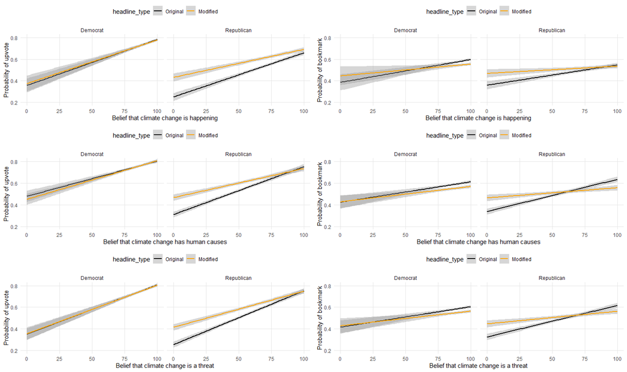

### Heterogeneity over Ideology

Table S27. Regression Results for Categorical Climate Belief

|  | Vote |  |  | Bookmark |  |  |
| --- | --- | --- | --- | --- | --- | --- |
| Predictors | Estimates | std. Error | p | Estimates | std. Error | p |
| Intercept | 0.638 | 0.014 | **<0.001** | 0.518 | 0.016 | **<0.001** |
| Prior | 0.178 | 0.016 | **<0.001** | 0.092 | 0.011 | **<0.001** |
| Ideology | -0.055 | 0.007 | **<0.001** | -0.011 | 0.005 | **0.031** |
| Treatment | -0.029 | 0.028 | 0.303 | 0.003 | 0.033 | 0.938 |
| Prior * Ideology | 0.012 | 0.015 | 0.405 | 0.012 | 0.010 | 0.237 |
| Prior * Treatment | 0.032 | 0.031 | 0.309 | 0.067 | 0.023 | **0.003** |
| Ideology * Treatment | -0.033 | 0.014 | **0.021** | -0.019 | 0.010 | 0.067 |
| Prior * Ideology * Treatment | 0.059 | 0.029 | **0.041** | 0.036 | 0.021 | 0.085 |
| Observations | 21989 |  |  | 21989 |  |  |
| Marginal R<sup>2</sup> / Conditional R<sup>2</sup> | 0.061 / 0.262 |  |  | 0.011 / 0.087 |  |  |

Note. All models include random intercepts for titles and subjects; predictors are categorical climate belief, treatment, ideology and all their interactions. DV is either bookmark or vote.

Table S28. Regression Results for Prior on Climate Change is Happening

|  | Vote |  |  | Bookmark |  |  |
| --- | --- | --- | --- | --- | --- | --- |
| Predictors | Estimates | std. Error | p | Estimates | std. Error | p |
| Intercept | 0.672 | 0.013 | **<0.001** | 0.537 | 0.016 | **<0.001** |
| Prior | 0.093 | 0.007 | **<0.001** | 0.035 | 0.005 | **<0.001** |
| Ideology | -0.046 | 0.006 | **<0.001** | -0.011 | 0.004 | **0.010** |
| Treatment | -0.015 | 0.026 | 0.561 | 0.015 | 0.032 | 0.629 |
| Prior * Ideology | -0.012 | 0.006 | **0.040** | -0.000 | 0.004 | 0.987 |
| Prior * Treatment | 0.009 | 0.014 | 0.496 | 0.024 | 0.010 | **0.017** |
| Ideology * Treatment | -0.021 | 0.012 | 0.064 | -0.014 | 0.008 | 0.096 |
| Prior * Ideology * Treatment | 0.033 | 0.011 | **0.003** | 0.008 | 0.008 | 0.324 |
| Observations | 21989 |  |  | 21989 |  |  |
| Marginal R<sup>2</sup> / Conditional R<sup>2</sup> | 0.067 / 0.262 |  |  | 0.009 / 0.088 |  |  |

Note. All models include random intercepts for titles and subjects; predictors are continuous prior on climate change is happening, treatment, ideology and all their interactions. DV is either bookmark or votes.

Table S29. Regression Results for Prior on Climate Change Caused by Humanity

|  | Vote |  |  | Bookmark |  |  |
| --- | --- | --- | --- | --- | --- | --- |
| Predictors | Estimates | std. Error | p | Estimates | std. Error | p |
| Intercept | 0.679 | 0.013 | **<0.001** | 0.541 | 0.016 | **<0.001** |
| Prior | 0.098 | 0.007 | **<0.001** | 0.052 | 0.005 | **<0.001** |
| Ideology | -0.036 | 0.006 | **<0.001** | 0.001 | 0.004 | 0.790 |
| Treatment | -0.011 | 0.026 | 0.673 | 0.023 | 0.032 | 0.470 |
| Prior * Ideology | 0.002 | 0.005 | 0.714 | 0.005 | 0.004 | 0.198 |
| Prior * Treatment | 0.020 | 0.013 | 0.134 | 0.037 | 0.010 | **<0.001** |
| Ideology * Treatment | -0.014 | 0.012 | 0.220 | -0.004 | 0.009 | 0.651 |
| Prior * Ideology * Treatment | 0.029 | 0.011 | **0.008** | 0.015 | 0.008 | 0.052 |
| Observations | 21989 |  |  | 21989 |  |  |
| Marginal R<sup>2</sup> / Conditional R<sup>2</sup> | 0.073 / 0.262 |  |  | 0.015 / 0.088 |  |  |

Note. All models include random intercepts for titles and subjects; predictors are continuous prior on climate change is caused by human activity, treatment, ideology and all their interactions. DV is either bookmark or votes.

Table S30. Regression Results for Prior on Climate Change is a Threat

|  | Vote |  |  | Bookmark |  |  |
| --- | --- | --- | --- | --- | --- | --- |
| Predictors | Estimates | std. Error | p | Estimates | std. Error | p |
| Intercept | 0.674 | 0.013 | **<0.001** | 0.540 | 0.016 | **<0.001** |
| Prior | 0.124 | 0.007 | **<0.001** | 0.053 | 0.005 | **<0.001** |
| Ideology | -0.024 | 0.006 | **<0.001** | 0.001 | 0.004 | 0.762 |
| Treatment | -0.015 | 0.026 | 0.568 | 0.021 | 0.032 | 0.519 |
| Prior * Ideology | -0.008 | 0.006 | 0.169 | 0.005 | 0.004 | 0.264 |
| Prior * Treatment | 0.024 | 0.013 | 0.070 | 0.032 | 0.010 | **0.002** |
| Ideology * Treatment | -0.012 | 0.012 | 0.312 | -0.007 | 0.009 | 0.435 |
| Prior * Ideology * Treatment | 0.022 | 0.011 | 0.052 | 0.012 | 0.008 | 0.145 |
| Observations | 21989 |  |  | 21989 |  |  |
| Marginal R<sup>2</sup> / Conditional R<sup>2</sup> | 0.088 / 0.262 |  |  | 0.015 / 0.088 |  |  |

Note. All models include random intercepts for titles and subjects; predictors are continuous prior on climate change is a threat, treatment, ideology and all their interactions. DV is either bookmark or votes.

### Heterogeneity over Interest in Science News

Table S31. Regression Results for Categorical Climate Belief

|  | Vote |  |  | Bookmark |  |  |
| --- | --- | --- | --- | --- | --- | --- |
| Predictors | Estimates | std. Error | p | Estimates | std. Error | p |
| Intercept | 0.625 | 0.013 | **<0.001** | 0.511 | 0.016 | **<0.001** |
| Prior | 0.217 | 0.012 | **<0.001** | 0.104 | 0.009 | **<0.001** |
| Interest | 0.062 | 0.006 | **<0.001** | 0.011 | 0.004 | **0.006** |
| Treatment | -0.054 | 0.026 | **0.040** | -0.012 | 0.032 | 0.702 |
| Prior * Interest | 0.010 | 0.011 | 0.400 | 0.018 | 0.008 | **0.028** |
| Prior * Treatment | 0.107 | 0.024 | **<0.001** | 0.101 | 0.018 | **<0.001** |
| Interest * Treatment | 0.002 | 0.011 | 0.871 | -0.000 | 0.008 | 0.969 |
| Prior * Interest * Treatment | -0.045 | 0.023 | **0.049** | 0.005 | 0.017 | 0.759 |
| Observations | 21934 |  |  | 21934 |  |  |
| Marginal R<sup>2</sup> / Conditional R<sup>2</sup> | 0.069 / 0.263 |  |  | 0.011 / 0.087 |  |  |

Note. All models include random intercepts for titles and subjects; predictors are categorical climate belief, treatment, interest in science news and all their interactions. DV is either bookmark or vote.

Table S32. Regression Results for Prior on Climate Change is Happening

|  | Vote |  |  | Bookmark |  |  |
| --- | --- | --- | --- | --- | --- | --- |
| Predictors | Estimates | std. Error | p | Estimates | std. Error | p |
| Intercept | 0.678 | 0.013 | **<0.001** | 0.536 | 0.016 | **<0.001** |
| Prior | 0.093 | 0.005 | **<0.001** | 0.038 | 0.004 | **<0.001** |
| Interest | 0.054 | 0.005 | **<0.001** | 0.012 | 0.004 | **0.001** |
| Treatment | -0.024 | 0.025 | 0.340 | 0.012 | 0.032 | 0.697 |
| Prior * Interest | -0.004 | 0.004 | 0.373 | 0.003 | 0.003 | 0.279 |
| Prior * Treatment | 0.043 | 0.011 | **<0.001** | 0.037 | 0.008 | **<0.001** |
| Interest * Treatment | -0.021 | 0.010 | **0.044** | -0.004 | 0.008 | 0.609 |
| Prior * Interest * Treatment | -0.023 | 0.009 | **0.007** | -0.001 | 0.006 | 0.831 |
| Observations | 21934 |  |  | 21934 |  |  |
| Marginal R<sup>2</sup> / Conditional R<sup>2</sup> | 0.071 / 0.263 |  |  | 0.009 / 0.088 |  |  |

Note. All models include random intercepts for titles and subjects; predictors are continuous prior on climate change is happening, treatment, interest in science news and all their interactions. DV is either bookmark or votes.

Table S33. Regression Results for Prior on Climate Change Caused by Humanity

|  | Vote |  |  | Bookmark |  |  |
| --- | --- | --- | --- | --- | --- | --- |
| Predictors | Estimates | std. Error | p | Estimates | std. Error | p |
| Intercept | 0.678 | 0.013 | **<0.001** | 0.537 | 0.016 | **<0.001** |
| Prior | 0.105 | 0.005 | **<0.001** | 0.052 | 0.004 | **<0.001** |
| Interest | 0.056 | 0.005 | **<0.001** | 0.012 | 0.004 | **0.002** |
| Treatment | -0.020 | 0.025 | 0.440 | 0.016 | 0.032 | 0.616 |
| Prior * Interest | -0.003 | 0.004 | 0.538 | 0.005 | 0.003 | 0.114 |
| Prior * Treatment | 0.049 | 0.010 | **<0.001** | 0.047 | 0.007 | **<0.001** |
| Interest * Treatment | -0.014 | 0.010 | 0.168 | -0.002 | 0.007 | 0.777 |
| Prior * Interest * Treatment | -0.027 | 0.009 | **0.002** | -0.003 | 0.007 | 0.645 |
| Observations | 21934 |  |  | 21934 |  |  |
| Marginal R<sup>2</sup> / Conditional R<sup>2</sup> | 0.082 / 0.263 |  |  | 0.015 / 0.087 |  |  |

Note. All models include random intercepts for titles and subjects; predictors are continuous prior on climate change is caused by human activity, treatment, interest in science news and all their interactions. DV is either bookmark or votes.

Table S34. Regression Results for Prior on Climate Change is a Threat

|  | Vote |  |  | Bookmark |  |  |
| --- | --- | --- | --- | --- | --- | --- |
| Predictors | Estimates | std. Error | p | Estimates | std. Error | p |
| Intercept | 0.678 | 0.013 | **<0.001** | 0.537 | 0.016 | **<0.001** |
| Prior | 0.120 | 0.005 | **<0.001** | 0.053 | 0.004 | **<0.001** |
| Interest | 0.051 | 0.005 | **<0.001** | 0.010 | 0.004 | **0.007** |
| Treatment | -0.021 | 0.025 | 0.407 | 0.014 | 0.032 | 0.647 |
| Prior * Interest | -0.002 | 0.004 | 0.717 | 0.004 | 0.003 | 0.216 |
| Prior * Treatment | 0.048 | 0.010 | **<0.001** | 0.043 | 0.008 | **<0.001** |
| Interest * Treatment | -0.012 | 0.010 | 0.205 | -0.001 | 0.007 | 0.855 |
| Prior * Interest * Treatment | -0.022 | 0.008 | **0.010** | -0.001 | 0.006 | 0.859 |
| Observations | 21934 |  |  | 21934 |  |  |
| Marginal R<sup>2</sup> / Conditional R<sup>2</sup> | 0.097 / 0.263 |  |  | 0.015 / 0.087 |  |  |

Note. All models include random intercepts for titles and subjects; predictors are continuous prior on climate change is a threat, treatment, interest in science news and all their interactions. DV is either bookmark or votes.

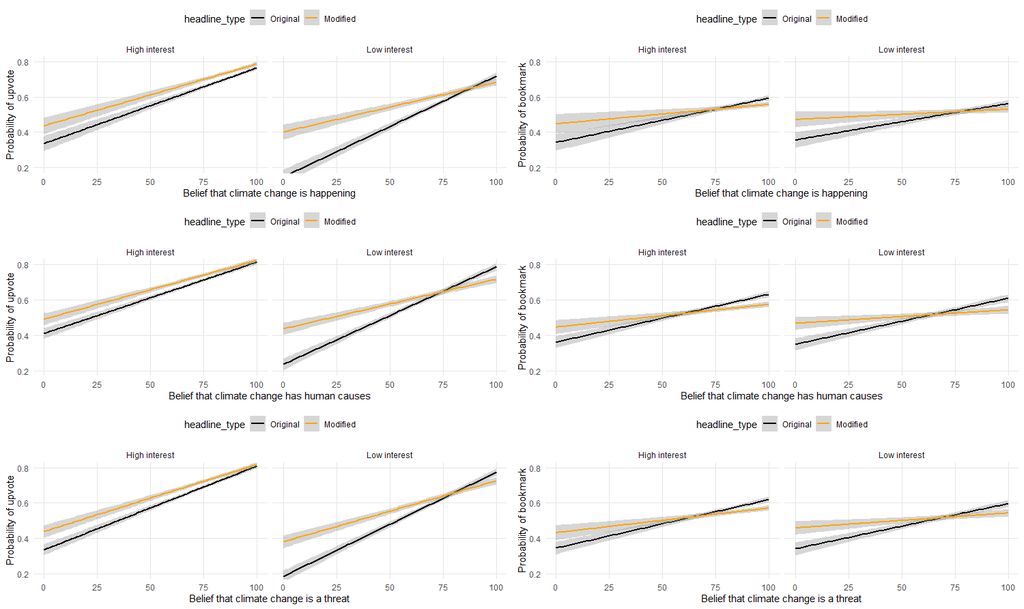

Figure S2: Logistic regression plots for upvote and bookmark probability over self-reported interest in science news

## Participant level heterogeneity on Regret and Credibility

### Heterogeneity over Age

Table S35. Regression Results for Categorical Climate Belief

|  | Credibility |  |  | Bookmark regret |  |  | Upvote regret |  |  |
| --- | --- | --- | --- | --- | --- | --- | --- | --- | --- |
| Predictors | Estimates | std. Error | p | Estimates | std. Error | p | Estimates | std. Error | p |
| Intercept | -0.150 | 0.035 | **<0.001** | -0.075 | 0.034 | **0.026** | 0.243 | 0.015 | **<0.001** |
| Prior | 0.679 | 0.052 | **<0.001** | 0.297 | 0.054 | **<0.001** | -0.176 | 0.025 | **<0.001** |
| Age | 0.032 | 0.026 | 0.209 | 0.117 | 0.027 | **<0.001** | 0.003 | 0.013 | 0.803 |
| Treatment | -0.030 | 0.070 | 0.664 | 0.053 | 0.068 | 0.435 | 0.030 | 0.030 | 0.309 |
| Prior * Age | 0.226 | 0.053 | **<0.001** | 0.006 | 0.055 | 0.920 | -0.012 | 0.026 | 0.638 |
| Prior * Treatment | -0.079 | 0.104 | 0.449 | -0.213 | 0.109 | 0.050 | -0.062 | 0.050 | 0.215 |
| Age * Treatment | 0.062 | 0.052 | 0.232 | 0.048 | 0.054 | 0.370 | -0.057 | 0.025 | **0.025** |
| Prior * Age * Treatment | 0.070 | 0.106 | 0.511 | -0.071 | 0.111 | 0.522 | 0.103 | 0.052 | **0.047** |
| Observations | 1966 |  |  | 1977 |  |  | 1621 |  |  |
| Marginal R<sup>2</sup> / Conditional R<sup>2</sup> | 0.104 / 0.135 |  |  | 0.028 / 0.052 |  |  | 0.036 / 0.061 |  |  |

Note. All models include random intercepts for titles and subjects; predictors are categorical climate belief, treatment, age and all their interactions. DV is either credibility of the article, bookmark regret, regretted upvotes.

Table S36. Regression Results for Prior on Climate Change is Happening

|  | Credibility |  |  | Bookmark regret |  |  | Upvote regret |  |  |
| --- | --- | --- | --- | --- | --- | --- | --- | --- | --- |
| Predictors | Estimates | std. Error | p | Estimates | std. Error | p | Estimates | std. Error | p |
| Intercept | -0.001 | 0.033 | 0.979 | -0.010 | 0.031 | 0.760 | 0.201 | 0.013 | **<0.001** |
| Prior | 0.352 | 0.022 | **<0.001** | 0.162 | 0.023 | **<0.001** | -0.076 | 0.012 | **<0.001** |
| Age | 0.093 | 0.021 | **<0.001** | 0.123 | 0.022 | **<0.001** | 0.001 | 0.010 | 0.894 |
| Treatment | -0.037 | 0.065 | 0.573 | 0.013 | 0.062 | 0.834 | 0.007 | 0.026 | 0.785 |
| Prior * Age | 0.026 | 0.023 | 0.264 | -0.037 | 0.024 | 0.128 | -0.005 | 0.012 | 0.671 |
| Prior * Treatment | -0.010 | 0.045 | 0.830 | -0.064 | 0.047 | 0.176 | 0.005 | 0.023 | 0.823 |
| Age * Treatment | 0.049 | 0.043 | 0.253 | 0.017 | 0.045 | 0.705 | -0.017 | 0.020 | 0.413 |
| Prior * Age * Treatment | 0.057 | 0.046 | 0.214 | -0.012 | 0.048 | 0.796 | 0.022 | 0.023 | 0.341 |
| Observations | 1966 |  |  | 1977 |  |  | 1621 |  |  |
| Marginal R<sup>2</sup> / Conditional R<sup>2</sup> | 0.129 / 0.164 |  |  | 0.035 / 0.060 |  |  | 0.036 / 0.060 |  |  |

Note. All models include random intercepts for titles and subjects; predictors are continuous prior on climate change is happening, treatment, age and all their interactions. DV is either credibility of the article, bookmark regret, regretted upvotes.

Table S37. Regression Results for Prior on Climate Change Caused by Humanity

|  | Credibility |  |  | Bookmark regret |  |  | Upvote regret |  |  |
| --- | --- | --- | --- | --- | --- | --- | --- | --- | --- |
| Predictors | Estimates | std. Error | p | Estimates | std. Error | p | Estimates | std. Error | p |
| Intercept | 0.005 | 0.032 | 0.882 | -0.010 | 0.031 | 0.740 | 0.199 | 0.013 | **<0.001** |
| Prior | 0.365 | 0.022 | **<0.001** | 0.163 | 0.024 | **<0.001** | -0.075 | 0.011 | **<0.001** |
| Age | 0.107 | 0.021 | **<0.001** | 0.127 | 0.023 | **<0.001** | 0.002 | 0.010 | 0.856 |
| Treatment | -0.023 | 0.064 | 0.723 | 0.010 | 0.062 | 0.866 | 0.016 | 0.026 | 0.537 |
| Prior * Age | 0.062 | 0.022 | **0.006** | -0.018 | 0.024 | 0.448 | -0.013 | 0.011 | 0.235 |
| Prior * Treatment | -0.067 | 0.044 | 0.127 | -0.109 | 0.047 | **0.021** | -0.034 | 0.022 | 0.122 |
| Age * Treatment | 0.066 | 0.042 | 0.119 | 0.021 | 0.045 | 0.640 | -0.039 | 0.020 | 0.056 |
| Prior * Age * Treatment | 0.050 | 0.045 | 0.265 | -0.042 | 0.048 | 0.377 | 0.062 | 0.022 | **0.005** |
| Observations | 1966 |  |  | 1977 |  |  | 1621 |  |  |
| Marginal R<sup>2</sup> / Conditional R<sup>2</sup> | 0.150 / 0.182 |  |  | 0.038 / 0.062 |  |  | 0.042 / 0.066 |  |  |

Note. All models include random intercepts for titles and subjects; predictors are continuous prior on climate change is caused by human activity, treatment, age and all their interactions. DV is either credibility of the article, bookmark regret, regretted upvotes.

Table S38. Regression Results for Prior on Climate Change is a Threat

|  | Credibility |  |  | Bookmark regret |  |  | Upvote regret |  |  |
| --- | --- | --- | --- | --- | --- | --- | --- | --- | --- |
| Predictors | Estimates | std. Error | p | Estimates | std. Error | p | Estimates | std. Error | p |
| Intercept | 0.003 | 0.031 | 0.935 | -0.009 | 0.031 | 0.767 | 0.204 | 0.013 | **<0.001** |
| Prior | 0.398 | 0.022 | **<0.001** | 0.181 | 0.023 | **<0.001** | -0.082 | 0.011 | **<0.001** |
| Age | 0.100 | 0.021 | **<0.001** | 0.126 | 0.022 | **<0.001** | 0.000 | 0.010 | 0.982 |
| Treatment | -0.028 | 0.062 | 0.646 | 0.013 | 0.061 | 0.829 | 0.007 | 0.026 | 0.781 |
| Prior * Age | 0.048 | 0.022 | **0.028** | -0.023 | 0.024 | 0.341 | -0.006 | 0.011 | 0.605 |
| Prior * Treatment | -0.043 | 0.043 | 0.315 | -0.070 | 0.046 | 0.131 | 0.004 | 0.023 | 0.867 |
| Age * Treatment | 0.081 | 0.041 | **0.050** | 0.033 | 0.045 | 0.457 | -0.027 | 0.020 | 0.180 |
| Prior * Age * Treatment | 0.026 | 0.044 | 0.558 | -0.016 | 0.047 | 0.731 | 0.021 | 0.023 | 0.351 |
| Observations | 1966 |  |  | 1977 |  |  | 1621 |  |  |
| Marginal R<sup>2</sup> / Conditional R<sup>2</sup> | 0.170 / 0.199 |  |  | 0.041 / 0.065 |  |  | 0.039 / 0.062 |  |  |

Note. All models include random intercepts for titles and subjects; predictors are continuous prior on climate change is a threat, treatment, age and all their interactions. DV is either credibility of the article, bookmark regret, regretted upvotes.

### Heterogeneity over Education

Table S39. Regression Results for Categorical Climate Belief

|  | Credibility |  |  | Bookmark regret |  |  | Upvote regret |  |  |
| --- | --- | --- | --- | --- | --- | --- | --- | --- | --- |
| Predictors | Estimates | std. Error | p | Estimates | std. Error | p | Estimates | std. Error | p |
| Intercept | -0.166 | 0.035 | **<0.001** | -0.064 | 0.034 | 0.065 | 0.237 | 0.015 | **<0.001** |
| Prior | 0.675 | 0.052 | **<0.001** | 0.228 | 0.055 | **<0.001** | -0.161 | 0.025 | **<0.001** |
| Education | -0.000 | 0.025 | 0.996 | 0.016 | 0.026 | 0.537 | 0.027 | 0.012 | **0.027** |
| Treatment | -0.062 | 0.070 | 0.381 | 0.069 | 0.069 | 0.319 | 0.012 | 0.030 | 0.688 |
| Prior * Education | 0.045 | 0.052 | 0.392 | 0.066 | 0.054 | 0.221 | -0.067 | 0.025 | **0.007** |
| Prior * Treatment | -0.014 | 0.105 | 0.892 | -0.218 | 0.109 | **0.046** | -0.037 | 0.050 | 0.461 |
| Education * Treatment | 0.094 | 0.051 | 0.062 | 0.022 | 0.053 | 0.680 | 0.004 | 0.024 | 0.856 |
| Prior * Education * Treatment | -0.235 | 0.104 | **0.024** | -0.052 | 0.109 | 0.632 | 0.021 | 0.050 | 0.668 |
| Observations | 1987 |  |  | 1999 |  |  | 1637 |  |  |
| Marginal R<sup>2</sup> / Conditional R<sup>2</sup> | 0.089 / 0.122 |  |  | 0.015 / 0.042 |  |  | 0.039 / 0.064 |  |  |

Note. All models include random intercepts for titles and subjects; predictors are categorical climate belief, treatment, education and all their interactions. DV is either credibility of the article, bookmark regret, regretted upvotes.

Table S40. Regression Results for Prior on Climate Change is Happening

|  | Credibility |  |  | Bookmark regret |  |  | Upvote regret |  |  |
| --- | --- | --- | --- | --- | --- | --- | --- | --- | --- |
| Predictors | Estimates | std. Error | p | Estimates | std. Error | p | Estimates | std. Error | p |
| Intercept | -0.006 | 0.033 | 0.853 | -0.010 | 0.032 | 0.747 | 0.200 | 0.013 | **<0.001** |
| Prior | 0.346 | 0.022 | **<0.001** | 0.140 | 0.023 | **<0.001** | -0.074 | 0.011 | **<0.001** |
| Education | 0.015 | 0.022 | 0.488 | 0.034 | 0.023 | 0.143 | 0.010 | 0.010 | 0.322 |
| Treatment | -0.050 | 0.066 | 0.448 | 0.022 | 0.064 | 0.738 | -0.001 | 0.026 | 0.979 |
| Prior * Education | 0.014 | 0.021 | 0.509 | -0.014 | 0.023 | 0.535 | -0.031 | 0.011 | **0.004** |
| Prior * Treatment | 0.023 | 0.043 | 0.600 | -0.043 | 0.045 | 0.344 | 0.006 | 0.022 | 0.771 |
| Education * Treatment | 0.032 | 0.043 | 0.461 | 0.004 | 0.046 | 0.923 | 0.005 | 0.020 | 0.786 |
| Prior * Education * Treatment | -0.069 | 0.043 | 0.105 | -0.071 | 0.045 | 0.117 | 0.029 | 0.021 | 0.174 |
| Observations | 1987 |  |  | 1999 |  |  | 1637 |  |  |
| Marginal R<sup>2</sup> / Conditional R<sup>2</sup> | 0.124 / 0.159 |  |  | 0.022 / 0.050 |  |  | 0.044 / 0.068 |  |  |

Note. All models include random intercepts for titles and subjects; predictors are continuous prior on climate change is happening, treatment, education and all their interactions. DV is either credibility of the article, bookmark regret, regretted upvotes.

Table S41. Regression Results for Prior on Climate Change Caused by Humanity

|  | Credibility |  |  | Bookmark regret |  |  | Upvote regret |  |  |
| --- | --- | --- | --- | --- | --- | --- | --- | --- | --- |
| Predictors | Estimates | std. Error | p | Estimates | std. Error | p | Estimates | std. Error | p |
| Intercept | -0.009 | 0.033 | 0.786 | -0.012 | 0.032 | 0.698 | 0.199 | 0.013 | **<0.001** |
| Prior | 0.362 | 0.022 | **<0.001** | 0.135 | 0.023 | **<0.001** | -0.072 | 0.011 | **<0.001** |
| Education | 0.015 | 0.022 | 0.486 | 0.034 | 0.023 | 0.145 | 0.010 | 0.010 | 0.340 |
| Treatment | -0.040 | 0.065 | 0.537 | 0.026 | 0.064 | 0.685 | -0.000 | 0.026 | 0.999 |
| Prior * Education | 0.014 | 0.021 | 0.528 | 0.003 | 0.023 | 0.909 | -0.028 | 0.011 | **0.010** |
| Prior * Treatment | -0.038 | 0.043 | 0.380 | -0.111 | 0.046 | **0.016** | -0.016 | 0.022 | 0.452 |
| Education * Treatment | 0.037 | 0.043 | 0.387 | 0.007 | 0.046 | 0.879 | 0.007 | 0.020 | 0.718 |
| Prior * Education * Treatment | -0.082 | 0.043 | 0.056 | -0.035 | 0.046 | 0.445 | 0.020 | 0.021 | 0.362 |
| Observations | 1987 |  |  | 1999 |  |  | 1637 |  |  |
| Marginal R<sup>2</sup> / Conditional R<sup>2</sup> | 0.137 / 0.170 |  |  | 0.023 / 0.050 |  |  | 0.043 / 0.067 |  |  |

Note. All models include random intercepts for titles and subjects; predictors are continuous prior on climate change is caused by human activity, treatment, education and all their interactions. DV is either credibility of the article, bookmark regret, regretted upvotes.

Table S42. Regression Results for Prior on Climate Change is a Threat

|  | Credibility |  |  | Bookmark regret |  |  | Upvote regret |  |  |
| --- | --- | --- | --- | --- | --- | --- | --- | --- | --- |
| Predictors | Estimates | std. Error | p | Estimates | std. Error | p | Estimates | std. Error | p |
| Intercept | -0.011 | 0.031 | 0.727 | -0.013 | 0.032 | 0.695 | 0.203 | 0.013 | **<0.001** |
| Prior | 0.397 | 0.021 | **<0.001** | 0.158 | 0.023 | **<0.001** | -0.080 | 0.011 | **<0.001** |
| Education | 0.023 | 0.021 | 0.277 | 0.037 | 0.023 | 0.107 | 0.007 | 0.010 | 0.489 |
| Treatment | -0.041 | 0.063 | 0.516 | 0.026 | 0.064 | 0.685 | 0.002 | 0.026 | 0.948 |
| Prior * Education | 0.001 | 0.021 | 0.976 | 0.004 | 0.023 | 0.876 | -0.016 | 0.011 | 0.151 |
| Prior * Treatment | -0.019 | 0.043 | 0.664 | -0.064 | 0.046 | 0.168 | 0.003 | 0.022 | 0.887 |
| Education * Treatment | 0.029 | 0.043 | 0.492 | 0.003 | 0.046 | 0.943 | 0.005 | 0.020 | 0.805 |
| Prior * Education * Treatment | -0.095 | 0.042 | **0.025** | -0.060 | 0.046 | 0.193 | 0.032 | 0.022 | 0.148 |
| Observations | 1987 |  |  | 1999 |  |  | 1637 |  |  |
| Marginal R<sup>2</sup> / Conditional R<sup>2</sup> | 0.161 / 0.191 |  |  | 0.028 / 0.055 |  |  | 0.042 / 0.066 |  |  |

Note. All models include random intercepts for titles and subjects; predictors are continuous prior on climate change is a threat, treatment, education and all their interactions. DV is either credibility of the article, bookmark regret, regretted upvotes.

### Heterogeneity over Sex

Table S43. Regression Results for Categorical Climate Belief

|  | Credibility |  |  | Bookmark regret |  |  | Upvote regret |  |  |
| --- | --- | --- | --- | --- | --- | --- | --- | --- | --- |
| Predictors | Estimates | std. Error | p | Estimates | std. Error | p | Estimates | std. Error | p |
| Intercept | -0.161 | 0.035 | **<0.001** | -0.059 | 0.034 | 0.082 | 0.243 | 0.015 | **<0.001** |
| Prior | 0.678 | 0.051 | **<0.001** | 0.246 | 0.053 | **<0.001** | -0.177 | 0.024 | **<0.001** |
| Sex | -0.025 | 0.025 | 0.306 | -0.027 | 0.025 | 0.298 | -0.001 | 0.012 | 0.936 |
| Treatment | -0.028 | 0.070 | 0.688 | 0.074 | 0.068 | 0.278 | 0.011 | 0.029 | 0.703 |
| Prior * Sex | 0.076 | 0.051 | 0.134 | 0.138 | 0.053 | **0.009** | -0.040 | 0.024 | 0.099 |
| Prior * Treatment | -0.093 | 0.102 | 0.359 | -0.241 | 0.106 | **0.023** | -0.028 | 0.048 | 0.560 |
| Sex * Treatment | -0.010 | 0.049 | 0.837 | 0.035 | 0.051 | 0.493 | -0.008 | 0.023 | 0.721 |
| Prior * Sex * Treatment | 0.017 | 0.101 | 0.865 | 0.091 | 0.105 | 0.387 | -0.035 | 0.048 | 0.472 |
| Observations | 1971 |  |  | 1983 |  |  | 1625 |  |  |
| Marginal R<sup>2</sup> / Conditional R<sup>2</sup> | 0.085 / 0.119 |  |  | 0.018 / 0.045 |  |  | 0.036 / 0.062 |  |  |

Note. All models include random intercepts for titles and subjects; predictors are categorical climate belief, treatment, sex and all their interactions. DV is either credibility of the article, bookmark regret, regretted upvotes.

Table S44. Regression Results for Prior on Climate Change is Happening

|  | Credibility |  |  | Bookmark regret |  |  | Upvote regret |  |  |
| --- | --- | --- | --- | --- | --- | --- | --- | --- | --- |
| Predictors | Estimates | std. Error | p | Estimates | std. Error | p | Estimates | std. Error | p |
| Intercept | -0.002 | 0.033 | 0.958 | -0.003 | 0.032 | 0.934 | 0.203 | 0.013 | **<0.001** |
| Prior | 0.348 | 0.021 | **<0.001** | 0.139 | 0.022 | **<0.001** | -0.084 | 0.010 | **<0.001** |
| Sex | -0.014 | 0.021 | 0.495 | 0.005 | 0.022 | 0.817 | -0.006 | 0.010 | 0.531 |
| Treatment | -0.037 | 0.066 | 0.576 | 0.019 | 0.064 | 0.771 | -0.002 | 0.026 | 0.944 |
| Prior * Sex | 0.054 | 0.021 | **0.010** | 0.051 | 0.022 | **0.023** | -0.036 | 0.010 | **0.001** |
| Prior * Treatment | 0.004 | 0.042 | 0.923 | -0.054 | 0.045 | 0.227 | 0.021 | 0.021 | 0.326 |
| Sex * Treatment | -0.013 | 0.042 | 0.763 | 0.057 | 0.044 | 0.194 | -0.020 | 0.019 | 0.300 |
| Prior * Sex * Treatment | 0.024 | 0.042 | 0.562 | 0.041 | 0.044 | 0.359 | 0.027 | 0.021 | 0.200 |
| Observations | 1971 |  |  | 1983 |  |  | 1625 |  |  |
| Marginal R<sup>2</sup> / Conditional R<sup>2</sup> | 0.122 / 0.158 |  |  | 0.023 / 0.052 |  |  | 0.044 / 0.069 |  |  |

Note. All models include random intercepts for titles and subjects; predictors are continuous prior on climate change is happening, treatment, sex and all their interactions. DV is either credibility of the article, bookmark regret, regretted upvotes.

Table S45. Regression Results for Prior on Climate Change Caused by Humanity

|  | Credibility |  |  | Bookmark regret |  |  | Upvote regret |  |  |
| --- | --- | --- | --- | --- | --- | --- | --- | --- | --- |
| Predictors | Estimates | std. Error | p | Estimates | std. Error | p | Estimates | std. Error | p |
| Intercept | -0.004 | 0.032 | 0.910 | -0.004 | 0.031 | 0.896 | 0.201 | 0.013 | **<0.001** |
| Prior | 0.361 | 0.021 | **<0.001** | 0.134 | 0.022 | **<0.001** | -0.078 | 0.010 | **<0.001** |
| Sex | -0.004 | 0.021 | 0.832 | 0.007 | 0.022 | 0.751 | -0.010 | 0.010 | 0.290 |
| Treatment | -0.026 | 0.065 | 0.690 | 0.025 | 0.063 | 0.691 | -0.001 | 0.026 | 0.975 |
| Prior * Sex | 0.015 | 0.021 | 0.485 | 0.036 | 0.022 | 0.102 | -0.023 | 0.010 | **0.024** |
| Prior * Treatment | -0.067 | 0.042 | 0.113 | -0.124 | 0.045 | **0.006** | -0.007 | 0.021 | 0.738 |
| Sex * Treatment | -0.000 | 0.042 | 0.997 | 0.060 | 0.044 | 0.175 | -0.020 | 0.019 | 0.309 |
| Prior * Sex * Treatment | 0.018 | 0.042 | 0.661 | 0.022 | 0.045 | 0.626 | -0.008 | 0.021 | 0.713 |
| Observations | 1971 |  |  | 1983 |  |  | 1625 |  |  |
| Marginal R<sup>2</sup> / Conditional R<sup>2</sup> | 0.133 / 0.166 |  |  | 0.024 / 0.051 |  |  | 0.041 / 0.066 |  |  |

Note. All models include random intercepts for titles and subjects; predictors are continuous prior on climate change is caused by human activity, treatment, sex and all their interactions. DV is either credibility of the article, bookmark regret, regretted upvotes.

Table S46. Regression Results for Prior on Climate Change is a Threat

|  | Credibility |  |  | Bookmark regret |  |  | Upvote regret |  |  |
| --- | --- | --- | --- | --- | --- | --- | --- | --- | --- |
| Predictors | Estimates | std. Error | p | Estimates | std. Error | p | Estimates | std. Error | p |
| Intercept | -0.001 | 0.031 | 0.978 | 0.000 | 0.031 | 0.994 | 0.202 | 0.013 | **<0.001** |
| Prior | 0.395 | 0.021 | **<0.001** | 0.156 | 0.022 | **<0.001** | -0.084 | 0.011 | **<0.001** |
| Sex | 0.015 | 0.021 | 0.461 | 0.016 | 0.022 | 0.472 | -0.012 | 0.010 | 0.214 |
| Treatment | -0.025 | 0.062 | 0.684 | 0.028 | 0.063 | 0.656 | -0.002 | 0.026 | 0.937 |
| Prior * Sex | 0.020 | 0.021 | 0.328 | 0.044 | 0.022 | **0.047** | -0.028 | 0.010 | **0.008** |
| Prior * Treatment | -0.047 | 0.042 | 0.264 | -0.081 | 0.045 | 0.072 | 0.016 | 0.021 | 0.450 |
| Sex * Treatment | 0.009 | 0.041 | 0.824 | 0.062 | 0.044 | 0.161 | -0.018 | 0.019 | 0.341 |
| Prior * Sex * Treatment | 0.035 | 0.041 | 0.395 | 0.047 | 0.044 | 0.286 | -0.013 | 0.021 | 0.519 |
| Observations | 1971 |  |  | 1983 |  |  | 1625 |  |  |
| Marginal R<sup>2</sup> / Conditional R<sup>2</sup> | 0.157 / 0.187 |  |  | 0.029 / 0.056 |  |  | 0.044 / 0.068 |  |  |

Note. All models include random intercepts for titles and subjects; predictors are continuous prior on climate change is a threat, treatment, sex and all their interactions. DV is either credibility of the article, bookmark regret, regretted upvotes.

### Heterogeneity over Partisanship

Table S47. Regression Results for Categorical Climate Belief

|  | Credibility |  |  | Bookmark regret |  |  | Upvote regret |  |  |
| --- | --- | --- | --- | --- | --- | --- | --- | --- | --- |
| Predictors | Estimates | std. Error | p | Estimates | std. Error | p | Estimates | std. Error | p |
| Intercept | -0.106 | 0.040 | **0.009** | -0.002 | 0.041 | 0.955 | 0.233 | 0.017 | **<0.001** |
| Prior | 0.519 | 0.067 | **<0.001** | 0.111 | 0.070 | 0.113 | -0.141 | 0.031 | **<0.001** |
| Partisanship | -0.127 | 0.030 | **<0.001** | -0.094 | 0.031 | **0.003** | 0.032 | 0.014 | **0.025** |
| Treatment | -0.080 | 0.081 | 0.321 | 0.041 | 0.082 | 0.616 | 0.089 | 0.035 | **0.010** |
| Prior * Partisanship | 0.090 | 0.061 | 0.140 | 0.116 | 0.064 | 0.069 | -0.017 | 0.029 | 0.565 |
| Prior * Treatment | -0.055 | 0.134 | 0.684 | -0.191 | 0.140 | 0.173 | -0.190 | 0.062 | **0.002** |
| Partisanship * Treatment | -0.006 | 0.060 | 0.915 | 0.024 | 0.063 | 0.709 | -0.108 | 0.029 | **<0.001** |
| Prior * Partisanship * Treatment | -0.181 | 0.122 | 0.137 | -0.108 | 0.128 | 0.398 | 0.195 | 0.058 | **0.001** |
| Observations | 1987 |  |  | 1999 |  |  | 1637 |  |  |
| Marginal R<sup>2</sup> / Conditional R<sup>2</sup> | 0.096 / 0.127 |  |  | 0.018 / 0.046 |  |  | 0.047 / 0.073 |  |  |

Note. All models include random intercepts for titles and subjects; predictors are categorical climate belief, treatment, partisanship and all their interactions. DV is either credibility of the article, bookmark regret, regretted upvotes.

Table S48. Regression Results for Prior on Climate Change is Happening

|  | Credibility |  |  | Bookmark regret |  |  | Upvote regret |  |  |
| --- | --- | --- | --- | --- | --- | --- | --- | --- | --- |
| Predictors | Estimates | std. Error | p | Estimates | std. Error | p | Estimates | std. Error | p |
| Intercept | -0.002 | 0.034 | 0.953 | 0.012 | 0.034 | 0.721 | 0.201 | 0.014 | **<0.001** |
| Prior | 0.317 | 0.029 | **<0.001** | 0.100 | 0.031 | **0.001** | -0.065 | 0.014 | **<0.001** |
| Partisanship | -0.072 | 0.024 | **0.003** | -0.046 | 0.025 | 0.071 | 0.027 | 0.011 | **0.017** |
| Treatment | -0.057 | 0.068 | 0.399 | 0.008 | 0.067 | 0.903 | 0.023 | 0.028 | 0.412 |
| Prior * Partisanship | -0.001 | 0.024 | 0.976 | 0.026 | 0.025 | 0.303 | -0.005 | 0.012 | 0.669 |
| Prior * Treatment | 0.013 | 0.058 | 0.826 | -0.028 | 0.061 | 0.651 | -0.035 | 0.029 | 0.224 |
| Partisanship * Treatment | -0.027 | 0.048 | 0.575 | 0.027 | 0.051 | 0.596 | -0.041 | 0.023 | 0.073 |
| Prior * Partisanship * Treatment | -0.030 | 0.047 | 0.517 | -0.029 | 0.050 | 0.567 | 0.045 | 0.024 | 0.058 |
| Observations | 1987 |  |  | 1999 |  |  | 1637 |  |  |
| Marginal R<sup>2</sup> / Conditional R<sup>2</sup> | 0.127 / 0.160 |  |  | 0.022 / 0.050 |  |  | 0.044 / 0.070 |  |  |

Note. All models include random intercepts for titles and subjects; predictors are continuous prior on climate change is happening, treatment, partisanship and all their interactions. DV is either credibility of the article, bookmark regret, regretted upvotes.

Table S49. Regression Results for Prior on Climate Change Caused by Humanity

|  | Credibility |  |  | Bookmark regret |  |  | Upvote regret |  |  |
| --- | --- | --- | --- | --- | --- | --- | --- | --- | --- |
| Predictors | Estimates | std. Error | p | Estimates | std. Error | p | Estimates | std. Error | p |
| Intercept | 0.011 | 0.035 | 0.747 | 0.030 | 0.034 | 0.382 | 0.196 | 0.014 | **<0.001** |
| Prior | 0.332 | 0.028 | **<0.001** | 0.082 | 0.030 | **0.007** | -0.064 | 0.013 | **<0.001** |
| Partisanship | -0.038 | 0.025 | 0.130 | -0.048 | 0.027 | 0.074 | 0.023 | 0.012 | 0.054 |
| Treatment | -0.060 | 0.069 | 0.388 | -0.002 | 0.069 | 0.977 | 0.037 | 0.029 | 0.202 |
| Prior * Partisanship | 0.029 | 0.024 | 0.219 | 0.061 | 0.026 | **0.017** | -0.012 | 0.012 | 0.311 |
| Prior * Treatment | -0.072 | 0.057 | 0.209 | -0.109 | 0.061 | 0.073 | -0.074 | 0.027 | **0.006** |
| Partisanship * Treatment | -0.061 | 0.050 | 0.226 | -0.014 | 0.053 | 0.795 | -0.068 | 0.024 | **0.004** |
| Prior * Partisanship * Treatment | -0.053 | 0.048 | 0.272 | -0.053 | 0.051 | 0.303 | 0.066 | 0.023 | **0.004** |
| Observations | 1987 |  |  | 1999 |  |  | 1637 |  |  |
| Marginal R<sup>2</sup> / Conditional R<sup>2</sup> | 0.137 / 0.170 |  |  | 0.026 / 0.054 |  |  | 0.048 / 0.074 |  |  |

Note. All models include random intercepts for titles and subjects; predictors are continuous prior on climate change is caused by human activity, treatment, partisanship and all their interactions. DV is either credibility of the article, bookmark regret, regretted upvotes.

Table S50. Regression Results for Prior on Climate Change is a Threat

|  | Credibility |  |  | Bookmark regret |  |  | Upvote regret |  |  |
| --- | --- | --- | --- | --- | --- | --- | --- | --- | --- |
| Predictors | Estimates | std. Error | p | Estimates | std. Error | p | Estimates | std. Error | p |
| Intercept | 0.011 | 0.033 | 0.748 | 0.015 | 0.034 | 0.657 | 0.194 | 0.014 | **<0.001** |
| Prior | 0.371 | 0.029 | **<0.001** | 0.128 | 0.031 | **<0.001** | -0.061 | 0.014 | **<0.001** |
| Partisanship | -0.023 | 0.025 | 0.343 | -0.027 | 0.027 | 0.310 | 0.027 | 0.012 | **0.026** |
| Treatment | -0.058 | 0.067 | 0.386 | 0.010 | 0.068 | 0.886 | 0.029 | 0.029 | 0.321 |
| Prior * Partisanship | 0.029 | 0.024 | 0.225 | 0.032 | 0.026 | 0.220 | -0.021 | 0.012 | 0.091 |
| Prior * Treatment | -0.037 | 0.057 | 0.515 | -0.054 | 0.062 | 0.384 | -0.039 | 0.029 | 0.178 |
| Partisanship * Treatment | -0.035 | 0.049 | 0.479 | 0.020 | 0.053 | 0.707 | -0.051 | 0.024 | **0.034** |
| Prior * Partisanship * Treatment | -0.052 | 0.048 | 0.287 | -0.033 | 0.052 | 0.533 | 0.051 | 0.025 | **0.043** |
| Observations | 1987 |  |  | 1999 |  |  | 1637 |  |  |
| Marginal R<sup>2</sup> / Conditional R<sup>2</sup> | 0.160 / 0.189 |  |  | 0.027 / 0.054 |  |  | 0.047 / 0.071 |  |  |

Note. All models include random intercepts for titles and subjects; predictors are continuous prior on climate change is a threat, treatment, partisanship and all their interactions. DV is either credibility of the article, bookmark regret, regretted upvotes.

### Heterogeneity over Ideology

Table S51. Regression Results for Categorical Climate Belief

|  | Credibility |  |  | Bookmark regret |  |  | Upvote regret |  |  |
| --- | --- | --- | --- | --- | --- | --- | --- | --- | --- |
| Predictors | Estimates | std. Error | p | Estimates | std. Error | p | Estimates | std. Error | p |
| Intercept | -0.103 | 0.040 | **0.010** | -0.007 | 0.040 | 0.864 | 0.227 | 0.017 | **<0.001** |
| Prior | 0.512 | 0.066 | **<0.001** | 0.118 | 0.069 | 0.086 | -0.122 | 0.030 | **<0.001** |
| Ideology | -0.138 | 0.030 | **<0.001** | -0.095 | 0.031 | **0.002** | 0.050 | 0.014 | **<0.001** |
| Treatment | -0.084 | 0.080 | 0.294 | 0.038 | 0.080 | 0.633 | 0.067 | 0.034 | **0.048** |
| Prior * Ideology | 0.110 | 0.061 | 0.068 | 0.111 | 0.063 | 0.078 | -0.030 | 0.028 | 0.292 |
| Prior * Treatment | -0.051 | 0.131 | 0.700 | -0.205 | 0.138 | 0.136 | -0.142 | 0.061 | **0.019** |
| Ideology * Treatment | 0.001 | 0.060 | 0.986 | 0.010 | 0.063 | 0.879 | -0.081 | 0.028 | **0.004** |
| Prior * Ideology * Treatment | -0.196 | 0.121 | 0.106 | -0.141 | 0.126 | 0.266 | 0.142 | 0.057 | **0.013** |
| Observations | 1987 |  |  | 1999 |  |  | 1637 |  |  |
| Marginal R<sup>2</sup> / Conditional R<sup>2</sup> | 0.098 / 0.130 |  |  | 0.019 / 0.046 |  |  | 0.049 / 0.073 |  |  |

Note. All models include random intercepts for titles and subjects; predictors are categorical climate belief, treatment, ideology and all their interactions. DV is either credibility of the article, bookmark regret, regretted upvotes.

Table S52. Regression Results for Prior on Climate Change is Happening

|  | Credibility |  |  | Bookmark regret |  |  | Upvote regret |  |  |
| --- | --- | --- | --- | --- | --- | --- | --- | --- | --- |
| Predictors | Estimates | std. Error | p | Estimates | std. Error | p | Estimates | std. Error | p |
| Intercept | 0.001 | 0.034 | 0.976 | 0.007 | 0.034 | 0.832 | 0.195 | 0.014 | **<0.001** |
| Prior | 0.313 | 0.029 | **<0.001** | 0.107 | 0.031 | **<0.001** | -0.051 | 0.014 | **<0.001** |
| Ideology | -0.072 | 0.024 | **0.003** | -0.044 | 0.025 | 0.082 | 0.043 | 0.011 | **<0.001** |
| Treatment | -0.044 | 0.068 | 0.520 | -0.002 | 0.067 | 0.977 | 0.018 | 0.028 | 0.522 |
| Prior * Ideology | 0.007 | 0.023 | 0.765 | 0.016 | 0.025 | 0.523 | -0.017 | 0.012 | 0.139 |
| Prior * Treatment | -0.012 | 0.058 | 0.831 | -0.027 | 0.061 | 0.654 | -0.023 | 0.029 | 0.418 |
| Ideology * Treatment | -0.036 | 0.048 | 0.452 | 0.003 | 0.051 | 0.953 | -0.030 | 0.023 | 0.194 |
| Prior * Ideology * Treatment | 0.003 | 0.047 | 0.949 | -0.048 | 0.050 | 0.335 | 0.028 | 0.023 | 0.226 |
| Observations | 1987 |  |  | 1999 |  |  | 1637 |  |  |
| Marginal R<sup>2</sup> / Conditional R<sup>2</sup> | 0.127 / 0.161 |  |  | 0.022 / 0.049 |  |  | 0.047 / 0.072 |  |  |

Note. All models include random intercepts for titles and subjects; predictors are continuous prior on climate change is happening, treatment, ideology and all their interactions. DV is either credibility of the article, bookmark regret, regretted upvotes.

Table S53. Regression Results for Prior on Climate Change Caused by Humanity

|  | Credibility |  |  | Bookmark regret |  |  | Upvote regret |  |  |
| --- | --- | --- | --- | --- | --- | --- | --- | --- | --- |
| Predictors | Estimates | std. Error | p | Estimates | std. Error | p | Estimates | std. Error | p |
| Intercept | 0.014 | 0.034 | 0.688 | 0.023 | 0.034 | 0.499 | 0.191 | 0.014 | **<0.001** |
| Prior | 0.325 | 0.028 | **<0.001** | 0.088 | 0.029 | **0.003** | -0.050 | 0.013 | **<0.001** |
| Ideology | -0.046 | 0.025 | 0.064 | -0.048 | 0.026 | 0.069 | 0.041 | 0.012 | **0.001** |
| Treatment | -0.062 | 0.068 | 0.362 | -0.003 | 0.068 | 0.970 | 0.024 | 0.028 | 0.396 |
| Prior * Ideology | 0.037 | 0.023 | 0.102 | 0.050 | 0.024 | **0.036** | -0.022 | 0.011 | 0.051 |
| Prior * Treatment | -0.069 | 0.055 | 0.209 | -0.120 | 0.059 | **0.041** | -0.055 | 0.026 | **0.038** |
| Ideology * Treatment | -0.063 | 0.049 | 0.203 | -0.040 | 0.053 | 0.446 | -0.052 | 0.023 | **0.028** |
| Prior * Ideology * Treatment | -0.057 | 0.045 | 0.204 | -0.054 | 0.048 | 0.266 | 0.039 | 0.022 | 0.080 |
| Observations | 1987 |  |  | 1999 |  |  | 1637 |  |  |
| Marginal R<sup>2</sup> / Conditional R<sup>2</sup> | 0.138 / 0.172 |  |  | 0.025 / 0.053 |  |  | 0.049 / 0.074 |  |  |

Note. All models include random intercepts for titles and subjects; predictors are continuous prior on climate change is caused by human activity, treatment, ideology and all their interactions. DV is either credibility of the article, bookmark regret, regretted upvotes.

Table S54. Regression Results for Prior on Climate Change is a Threat

|  | Credibility |  |  | Bookmark regret |  |  | Upvote regret |  |  |
| --- | --- | --- | --- | --- | --- | --- | --- | --- | --- |
| Predictors | Estimates | std. Error | p | Estimates | std. Error | p | Estimates | std. Error | p |
| Intercept | 0.013 | 0.033 | 0.704 | 0.012 | 0.034 | 0.717 | 0.193 | 0.014 | **<0.001** |
| Prior | 0.368 | 0.029 | **<0.001** | 0.131 | 0.031 | **<0.001** | -0.050 | 0.014 | **0.001** |
| Ideology | -0.025 | 0.025 | 0.307 | -0.027 | 0.027 | 0.314 | 0.043 | 0.012 | **<0.001** |
| Treatment | -0.062 | 0.066 | 0.348 | 0.011 | 0.068 | 0.868 | 0.027 | 0.028 | 0.336 |
| Prior * Ideology | 0.034 | 0.024 | 0.149 | 0.027 | 0.026 | 0.284 | -0.025 | 0.012 | **0.042** |
| Prior * Treatment | -0.036 | 0.058 | 0.529 | -0.073 | 0.062 | 0.243 | -0.032 | 0.029 | 0.268 |
| Ideology * Treatment | -0.042 | 0.049 | 0.392 | -0.013 | 0.053 | 0.806 | -0.039 | 0.024 | 0.100 |
| Prior * Ideology * Treatment | -0.060 | 0.048 | 0.211 | -0.029 | 0.051 | 0.577 | 0.045 | 0.024 | 0.067 |
| Observations | 1987 |  |  | 1999 |  |  | 1637 |  |  |
| Marginal R<sup>2</sup> / Conditional R<sup>2</sup> | 0.161 / 0.190 |  |  | 0.027 / 0.054 |  |  | 0.050 / 0.073 |  |  |

Note. All models include random intercepts for titles and subjects; predictors are continuous prior on climate change is a threat, treatment, ideology and all their interactions. DV is either credibility of the article, bookmark regret, regretted upvotes.

### Heterogeneity over Interest in Science News

Table S55. Regression Results for Categorical Climate Belief

|  | Credibility |  |  | Bookmark regret |  |  | Upvote regret |  |  |
| --- | --- | --- | --- | --- | --- | --- | --- | --- | --- |
| Predictors | Estimates | std. Error | p | Estimates | std. Error | p | Estimates | std. Error | p |
| Intercept | -0.154 | 0.035 | **<0.001** | -0.042 | 0.034 | 0.218 | 0.246 | 0.014 | **<0.001** |
| Prior | 0.634 | 0.051 | **<0.001** | 0.179 | 0.053 | **0.001** | -0.170 | 0.024 | **<0.001** |
| Interest | 0.160 | 0.023 | **<0.001** | 0.187 | 0.024 | **<0.001** | -0.049 | 0.012 | **<0.001** |
| Treatment | -0.029 | 0.070 | 0.681 | 0.066 | 0.068 | 0.330 | 0.013 | 0.029 | 0.661 |
| Prior * Interest | -0.004 | 0.048 | 0.927 | -0.007 | 0.050 | 0.888 | 0.008 | 0.024 | 0.727 |
| Prior * Treatment | -0.076 | 0.103 | 0.459 | -0.193 | 0.107 | 0.070 | -0.045 | 0.049 | 0.361 |
| Interest * Treatment | 0.087 | 0.046 | 0.060 | 0.064 | 0.048 | 0.180 | -0.025 | 0.023 | 0.291 |
| Prior * Interest * Treatment | -0.194 | 0.096 | **0.044** | -0.076 | 0.100 | 0.444 | 0.093 | 0.048 | 0.053 |
| Observations | 1982 |  |  | 1994 |  |  | 1633 |  |  |
| Marginal R<sup>2</sup> / Conditional R<sup>2</sup> | 0.114 / 0.146 |  |  | 0.047 / 0.073 |  |  | 0.049 / 0.073 |  |  |

Note. All models include random intercepts for titles and subjects; predictors are categorical climate belief, treatment, interest in science news and all their interactions. DV is either credibility of the article, bookmark regret, regretted upvotes.

Table S56. Regression Results for Prior on Climate Change is Happening

|  | Credibility |  |  | Bookmark regret |  |  | Upvote regret |  |  |
| --- | --- | --- | --- | --- | --- | --- | --- | --- | --- |
| Predictors | Estimates | std. Error | p | Estimates | std. Error | p | Estimates | std. Error | p |
| Intercept | 0.002 | 0.033 | 0.959 | -0.000 | 0.031 | 0.991 | 0.204 | 0.013 | **<0.001** |
| Prior | 0.316 | 0.022 | **<0.001** | 0.098 | 0.024 | **<0.001** | -0.078 | 0.011 | **<0.001** |
| Interest | 0.120 | 0.022 | **<0.001** | 0.175 | 0.023 | **<0.001** | -0.040 | 0.010 | **<0.001** |
| Treatment | -0.029 | 0.065 | 0.652 | 0.032 | 0.062 | 0.605 | -0.008 | 0.025 | 0.749 |
| Prior * Interest | -0.018 | 0.018 | 0.315 | 0.001 | 0.019 | 0.972 | 0.017 | 0.010 | 0.088 |
| Prior * Treatment | -0.012 | 0.045 | 0.787 | -0.070 | 0.047 | 0.137 | 0.014 | 0.022 | 0.534 |
| Interest * Treatment | 0.013 | 0.043 | 0.763 | 0.037 | 0.045 | 0.419 | -0.004 | 0.021 | 0.856 |
| Prior * Interest * Treatment | -0.073 | 0.036 | **0.039** | -0.052 | 0.037 | 0.163 | 0.066 | 0.020 | **0.001** |
| Observations | 1982 |  |  | 1994 |  |  | 1633 |  |  |
| Marginal R<sup>2</sup> / Conditional R<sup>2</sup> | 0.140 / 0.174 |  |  | 0.050 / 0.076 |  |  | 0.055 / 0.077 |  |  |

Note. All models include random intercepts for titles and subjects; predictors are continuous prior on climate change is happening, treatment, interest in science news and all their interactions. DV is either credibility of the article, bookmark regret, regretted upvotes.

Table S57. Regression Results for Prior on Climate Change Caused by Humanity

|  | Credibility |  |  | Bookmark regret |  |  | Upvote regret |  |  |
| --- | --- | --- | --- | --- | --- | --- | --- | --- | --- |
| Predictors | Estimates | std. Error | p | Estimates | std. Error | p | Estimates | std. Error | p |
| Intercept | -0.001 | 0.032 | 0.969 | 0.002 | 0.031 | 0.941 | 0.203 | 0.013 | **<0.001** |
| Prior | 0.340 | 0.021 | **<0.001** | 0.098 | 0.023 | **<0.001** | -0.076 | 0.010 | **<0.001** |
| Interest | 0.125 | 0.021 | **<0.001** | 0.172 | 0.023 | **<0.001** | -0.042 | 0.010 | **<0.001** |
| Treatment | -0.026 | 0.065 | 0.691 | 0.030 | 0.062 | 0.630 | -0.004 | 0.026 | 0.861 |
| Prior * Interest | -0.019 | 0.019 | 0.304 | -0.021 | 0.020 | 0.293 | 0.016 | 0.010 | 0.113 |
| Prior * Treatment | -0.061 | 0.043 | 0.153 | -0.110 | 0.045 | **0.015** | -0.019 | 0.021 | 0.365 |
| Interest * Treatment | 0.055 | 0.043 | 0.201 | 0.054 | 0.045 | 0.232 | -0.001 | 0.021 | 0.966 |
| Prior * Interest * Treatment | -0.058 | 0.038 | 0.122 | -0.047 | 0.040 | 0.243 | 0.056 | 0.020 | **0.006** |
| Observations | 1982 |  |  | 1994 |  |  | 1633 |  |  |
| Marginal R<sup>2</sup> / Conditional R<sup>2</sup> | 0.153 / 0.187 |  |  | 0.053 / 0.079 |  |  | 0.054 / 0.077 |  |  |

Note. All models include random intercepts for titles and subjects; predictors are continuous prior on climate change is caused by human activity, treatment, interest in science news and all their interactions. DV is either credibility of the article, bookmark regret, regretted upvotes.

Table S58. Regression Results for Prior on Climate Change is a Threat

|  | Credibility |  |  | Bookmark regret |  |  | Upvote regret |  |  |
| --- | --- | --- | --- | --- | --- | --- | --- | --- | --- |
| Predictors | Estimates | std. Error | p | Estimates | std. Error | p | Estimates | std. Error | p |
| Intercept | 0.005 | 0.031 | 0.871 | 0.002 | 0.031 | 0.937 | 0.206 | 0.013 | **<0.001** |
| Prior | 0.367 | 0.021 | **<0.001** | 0.120 | 0.023 | **<0.001** | -0.080 | 0.011 | **<0.001** |
| Interest | 0.111 | 0.021 | **<0.001** | 0.169 | 0.023 | **<0.001** | -0.042 | 0.010 | **<0.001** |
| Treatment | -0.034 | 0.063 | 0.592 | 0.025 | 0.062 | 0.684 | -0.002 | 0.026 | 0.934 |
| Prior * Interest | -0.041 | 0.018 | **0.025** | -0.013 | 0.020 | 0.517 | 0.016 | 0.010 | 0.116 |
| Prior * Treatment | -0.041 | 0.043 | 0.344 | -0.064 | 0.046 | 0.162 | 0.003 | 0.022 | 0.890 |
| Interest * Treatment | 0.055 | 0.042 | 0.193 | 0.051 | 0.045 | 0.261 | -0.009 | 0.021 | 0.680 |
| Prior * Interest * Treatment | -0.035 | 0.036 | 0.336 | -0.019 | 0.039 | 0.628 | 0.046 | 0.021 | **0.028** |
| Observations | 1982 |  |  | 1994 |  |  | 1633 |  |  |
| Marginal R<sup>2</sup> / Conditional R<sup>2</sup> | 0.175 / 0.206 |  |  | 0.055 / 0.081 |  |  | 0.053 / 0.076 |  |  |

Note. All models include random intercepts for titles and subjects; predictors are continuous prior on climate change is a threat, treatment, interest in science news and all their interactions. DV is either credibility of the article, bookmark regret, regretted upvotes.

## Robustness check with logistic regression analysis

For robustness check, we also conducted a logistic regression analysis on the engagement results as the the outcome variables were binary. The results were consistent with the linear regression analysis of these measures.

Table S56. Logistic Regression Results for Categorical Climate Belief

|  | Vote |  |  | Bookmark |  |  |
| --- | --- | --- | --- | --- | --- | --- |
| Predictors | Odds Ratios | std. Error | p | Odds Ratios | std. Error | p |
| Intercept | 1.977 | 0.152 | **<0.001** | 1.048 | 0.072 | 0.500 |
| Prior | 4.052 | 0.299 | **<0.001** | 1.597 | 0.060 | **<0.001** |
| Treatment | 0.756 | 0.117 | 0.070 | 0.957 | 0.132 | 0.750 |
| Prior * Treatment | 1.595 | 0.234 | **0.001** | 1.535 | 0.115 | **<0.001** |
| Observations | 21989 |  |  | 21989 |  |  |
| Marginal R<sup>2</sup> / Conditional R<sup>2</sup> | 0.070 / 0.380 |  |  | 0.013 / 0.109 |  |  |

Note. All models include random intercepts for titles and subjects; predictors are categorical prior belief, treatment and their interaction. DV is either bookmark or votes.

Table S57. Logistic Regression Results for Prior on Climate Change is Happening

|  | Vote |  |  | Bookmark |  |  |
| --- | --- | --- | --- | --- | --- | --- |
| Predictors | Odds Ratios | std. Error | p | Odds Ratios | std. Error | p |
| Intercept | 2.739 | 0.207 | **<0.001** | 1.171 | 0.081 | **0.022** |
| Prior | 1.857 | 0.058 | **<0.001** | 1.191 | 0.019 | **<0.001** |
| Treatment | 0.859 | 0.129 | 0.314 | 1.062 | 0.146 | 0.662 |
| Prior * Treatment | 1.250 | 0.078 | **<0.001** | 1.175 | 0.038 | **<0.001** |
| Observations | 21989 |  |  | 21989 |  |  |
| Marginal R<sup>2</sup> / Conditional R<sup>2</sup> | 0.077 / 0.380 |  |  | 0.010 / 0.110 |  |  |

Note. All models include random intercepts for titles and subjects; predictors are continuous prior on climate change is happening, treatment and their interaction. DV is either bookmark or votes.

Table S58. Logistic Regression Results for Prior on Climate Change Caused by Humanity

|  | Vote |  |  | Bookmark |  |  |
| --- | --- | --- | --- | --- | --- | --- |
| Predictors | Odds Ratios | std. Error | p | Odds Ratios | std. Error | p |
| Intercept | 2.746 | 0.207 | **<0.001** | 1.174 | 0.081 | **0.020** |
| Prior | 1.981 | 0.061 | **<0.001** | 1.267 | 0.020 | **<0.001** |
| Treatment | 0.889 | 0.134 | 0.435 | 1.076 | 0.148 | 0.594 |
| Prior * Treatment | 1.251 | 0.076 | **<0.001** | 1.228 | 0.039 | **<0.001** |
| Observations | 21989 |  |  | 21989 |  |  |
| Marginal R<sup>2</sup> / Conditional R<sup>2</sup> | 0.093 / 0.379 |  |  | 0.019 / 0.110 |  |  |

Note. All models include random intercepts for titles and subjects; predictors are continuous prior on climate change is caused by human activity, treatment and their interaction. DV is either bookmark or votes.

Table S59. Logistic Regression Results for Prior on Climate Change is a Threat

|  | Vote |  |  | Bookmark |  |  |
| --- | --- | --- | --- | --- | --- | --- |
| Predictors | Odds Ratios | std. Error | p | Odds Ratios | std. Error | p |
| Intercept | 2.718 | 0.204 | **<0.001** | 1.172 | 0.080 | **0.021** |
| Prior | 2.128 | 0.063 | **<0.001** | 1.271 | 0.020 | **<0.001** |
| Treatment | 0.887 | 0.133 | 0.423 | 1.071 | 0.147 | 0.616 |
| Prior * Treatment | 1.259 | 0.074 | **<0.001** | 1.206 | 0.038 | **<0.001** |
| Observations | 21989 |  |  | 21989 |  |  |
| Marginal R<sup>2</sup> / Conditional R<sup>2</sup> | 0.114 / 0.377 |  |  | 0.019 / 0.110 |  |  |

Note. All models include random intercepts for titles and subjects; predictors are continuous prior on climate change is a threat, treatment and their interaction. DV is either bookmark or votes.

### Prior and Posterior Beliefs

**Question:**

> Recently, you may have noticed that global warming has been getting some attention in the news. Global warming refers to the idea that the world’s average temperature has been increasing over the past 150 years, may be increasing more in the future, and that the world’s climate may change as a result. What do you think: Do you think that global warming is happening?

**Answer Options:** 1. Yes  
2. No  
3. Don’t know

**Question (categorical climate belief):**

> Assuming global warming is happening, do you think it is… ?

**Answer Options:** 1. Caused mostly by human activities 2. Caused mostly by natural changes in the environment 3. None of the above because global warming is not happening 4. Other 5. Don’t know

**Question (belief that climate change is caused by human activity):**

> What is the probability that climate change is primarily caused by human activity? [Scale of 0 (very unlikely) to 100 (very likely)]

**Question (belief that climate change is happening):**

> What is the probability that climate change is happening? [Scale of 0 (very unlikely) to 100 (very likely)]

**Question (belief that climate change is a threat):**

> How significant is the threat climate change poses to human safety, world and national economies or biodiversity? [Scale of 0 (not significant) to 100 (very significant)]

### Ideology and Partisanship

**Question (ideology on economic issues):**

> In general, how would you describe your own political viewpoint on economic issues?

**Answer Options:** 1. Very liberal 2. Liberal 3. Moderate 4. Conservative 5. Very conservative 6. Note sure

**Question (ideology on social issues):**

> In general, how would you describe your own political viewpoint on social issues?

**Answer Options:** 1. Very liberal 2. Liberal 3. Moderate 4. Conservative 5. Very conservative 6. Note sure

**Question (partisanship):**

> Which of the following best describes your political preference?

**Answer Options:** 1. Strongly Democratic 2. Democratic 3. Lean Democratic 4. Lean Republican 5. Republican 6. Strongly Republican

### All original and flipped headlines in the experiment

| Outlet | Original Headline | Flipped Headline | Source URL |
| --- | --- | --- | --- |
| Vox | How La Niña will shape heat and hurricanes this year | Pacific Ocean Cycle Shift Could Bring New Weather Patterns | https://www.vox.com/climate/24145756/la-nina-2024-el-nino-heat-hurricane-record-temperature-pacific |
| Vox | We could be heading into the hottest summer of our lives | Summer Heat Wave Expected to Bring Extreme Weather Events to the US | https://www.vox.com/science/24141780/summer-hot-national-weather-service |
| USA Today | Climate science is sound. Satellite timelapse doesn’t disprove sea level rise \| Fact check | Experts Say Satellite Images Alone Can’t Detect Sea Level Rise | https://www.usatoday.com/story/news/factcheck/2024/04/29/no-satellite-timelapse-doesnt-disprove-climate-change-fact-check/73285056007/ |
| BBC | Climate change made UK’s waterlogged winter worse | UK Farmers Struggle with Wet Winter Conditions | https://www.bbc.com/news/articles/cp992nxxe7do.amp |
| BBC | Why the world’s oceans are changing colour | Ocean’s Color Changing Due to Shift in Phytoplankton Populations | https://www.bbc.com/future/article/20240517-are-the-oceans-changing-colour-because-of-climate-change?embed=true |
| BBC | Mycelium Matters: How Mushrooms Can Address Climate Change | Mushrooms’ Hidden Power: Unleashing the Potential of Mycelium | https://www.bbc.com/storyworks/climate-academy/mycelium-matters |
| National Geographic | Deserts, explained | Deserts: The Unseen Wonders of the Natural World | https://www.nationalgeographic.com/environment/article/deserts |
| National Geographic | Extreme Research Shows How Arctic Ice Is Dwindling | Uncovering the Mysteries of Arctic Sea Ice: A Five-Month Research Expedition | https://www.nationalgeographic.com/magazine/article/arctic-ice-environment |
| CBS | Asia just had a deadly heat wave, and scientists say it could happen again. Here’s what’s making it much more likely. | Asia Suffers Deadly Heat Wave, Hundreds of Deaths Reported | https://www.cbsnews.com/news/asia-deadly-heat-wave-india-bangladesh-climate-change/ |
| BBC | Aircraft turbulence is worsening with climate change. Studying birds could help | Birds May Hold the Key to Predicting Turbulent Skies | https://www.bbc.com/future/article/20240524-severe-turbulence-climate-change-singapore-airlines |
| BBC | In a warmer world, tornado behaviour is changing – this is how we can prepare | Preparing for the Unpredictable: How to Stay Safe in Tornado Alley | https://www.bbc.com/future/article/20240522-climate-change-experts-advise-how-to-prepare-for-a-tornado |
| BBC | Climate plan will build resilience, says council | Council Takes Proactive Approach to Managing Weather-Related Risks | https://www.bbc.com/news/articles/cqqq34nzp6lo |
| BBC | Extreme weather making it harder to be active | Sport England Unveils £45m Package to Tackle Environmental Challenges | https://www.bbc.com/sport/articles/c6pyp3dpqqvo.amp |
| BBC | Inside the giant ‘sky rivers’ swelling with climate change | Chasing the Storm: Scientists Fly into Atmospheric Rivers to Improve Forecasts | https://www.bbc.com/future/article/20240509-how-to-forecast-the-next-atmospheric-river-storms |
| BBC | Climate change: World’s oceans suffer from record-breaking year of heat | El Niño Event Contributes to Unprecedented Ocean Warming | https://www.bbc.com/news/science-environment-68921215 |
| BBC | The foods that reverse climate change | Precision Agriculture and Gene-Editing: The Future of Food Production? | https://www.bbc.com/future/bespoke/follow-the-food/the-foods-that-reverse-climate-change |
| BBC | What Antarctica can teach us about global climate change | Deciphering the Past to Predict the Future: International Research Efforts in Antarctica | https://www.bbc.com/storyworks/specials/unlocking-science/what-antarctica-can-teach-us-about-global-climate-change/ |
| The Guardian | UK is failing to put climate crisis at centre of national security measures, MPs told | Experts Warn of Growing Threats to Global Stability | https://www.theguardian.com/environment/article/2024/may/14/uk-is-failing-to-put-climate-crisis-at-centre-of-national-security-measures-mps-told |
| The Guardian | Climate change driving demand for predatory loans, research shows | Low-Income Households Struggle to Cope with Rising Utility Bills and Debt | https://www.theguardian.com/us-news/2024/apr/15/predatory-loans-heatwaves-cold-snaps |
| The Guardian | Brazil is reeling from catastrophic floods. What went wrong – and what does the future hold? | Brazil’s Southern State Devastated by Record Rainfall and Flooding | https://www.theguardian.com/global-development/article/2024/may/10/brazil-is-reeling-from-catastrophic-floods-what-went-wrong-and-what-does-the-future-hold?ref=upstract.com |
| The Guardian | Glacial lakes threaten millions with flooding as planet heats up | Rising Number of People Threatened by Glacial Lake Outburst Floods, Scientists Warn | https://www.theguardian.com/environment/2021/may/02/glacial-lakes-threaten-millions-with-floods-as-planet-heats-up |
| National Geographic | The world’s historic sites face climate change. Can Petra lead the way? | Ancient Desert City of Petra Faces Modern-Day Challenges | https://www.nationalgeographic.com/premium/article/petra-ancient-technology-climate-change-floods |
| National Geographic | What a Simple Psychological Test Reveals About Climate Change | The Tragedy of the Commons: A Classroom Experiment Reveals the Power of Collective Action | https://www.nationalgeographic.com/magazine/article/embark-essay-tragedy-of-the-commons-greed-common-good |
| National Geographic | Alaska’s Thaw Reveals—and Threatens—a Culture’s Artifacts | Uncovering the Secrets of Alaska’s Yupik People as Permafrost Thaws | https://www.nationalgeographic.com/magazine/article/artifact-melt-alaska-archaeology-climate-change |
| NBC | Are migraines getting worse? | Migraines on the Rise: Study Finds Increase in Frequency and Severity Among Americans | https://www.nbcnews.com/health/health-news/climate-change-may-linked-rising-migraine-severity-frequency-americans-rcna150868?cid=eml_mrd_20240516 |
| CBS | Mysterious origin of the “tree of life” revealed as some of the species is just decades from extinction | Ancient ‘Tree of Life’ Finally Has Its Origins Traced | https://www.cbsnews.com/news/baobab-tree-of-life-origin/ |
| CBS | Can you die from airplane turbulence? What causes it, and how to stay safe on a rough flight. | Flight Turbulence: What Causes It and How Can Passengers Stay Safe? | https://www.cbsnews.com/news/flight-turbulence-airplane-causes-what-to-know/ |
| CBS | Bay Area scientists use game-changing technology to help birds amid climate change | Cutting-Edge Technology Helps Scientists Track Decline in Bird Populations | https://www.cbsnews.com/sanfrancisco/news/project-earth-birds-motus-wildlife-tracking-system-bay-area-scientists-climate-change/ |